# Ramadan estimation

# Appendix figures and tables

## Full results

Results for boys and girls.

For a more concise table, refer to the main text.

**Click here to see the code of showing full results.**

```r
#### Uses tabs2latex4
##### results <- qread("../save/DID2024_MainResults.qs")
jj <- s <- de <- 1
j <- clnum <- 2
m <- 3
ii <- 1
for (ge in c(3, 1, 2)) {
  rgs <- lapply(results[[ii]][[jj]][[s]][[j]][[ge]][[m]][[clnum]], "[[", "reg")
  cis0 <- lapply(results[[ii]][[jj]][[s]][[j]][[ge]][[m]][[clnum]], "[[", "ci")
  source("../program/tabulate_est.R")
  #### Need: estimates, SE, p, lb, ub,
  cis0 <- lapply(cis0, data.table)
  cis <- lapply(cis0, function(x) x[, df := NULL])
  cis <- lapply(cis, function(x) {
   dm <- data.frame(x[, -1])
   rownames(dm) <- as.character(unlist(x[, 1]))
   dm
   })
  tab <- tabs2latex4(cis, informat = "sattCI", outformat = OUTFORMAT,
    xx.yyy = T, AddStarIntabstarP = ADDStar, CIIntinysize = T,
    Pparenthesis = "brace", UseHTML = T)
  rn <- rownames(tab)
  rn[-seq(1, length(rn), plusrows+1)] <- ""
  tabmat <- as.matrix(tab)
  rownames(tabmat) <- rn
  ####  replace variable names, deleting std error names
  rnm <- rn
  for (k in 1:nrow(sbt)){
    if (any(grepl(sbt[k, "org"], rnm)))
      rnm[grep(sbt[k, "org"], rnm)] <- sbt[k, "changedto"]
  }
  rnm <- gsub("Number of ol", "Ol", rnm)
  rnm <- gsub("\\$\\\\times\\$ year.*", "", rnm)
  rnm <- gsub("\\$\\\\times\\$ ag ?HH", "", rnm)
  rnm <- gsub("\\\\hspace\\{.*?\\}", "", rnm)
  rownames(tabmat) <- rnm
  for (iii in 1:ncol(tabmat)) {
    tabmat[, iii] <- gsub("\\\\mbox\\{\\\\tiny ?(.*)\\}", "\\1", tabmat[, iii])
    tabmat[, iii] <- gsub("\\\\phantom\\{.*?\\}", "", tabmat[, iii])
    tabmat[, iii] <- gsub("\\^\\{(.*)\\}", "", tabmat[, iii])
  }
  tabmat <- rbind(tabmat,
  ####  "Thana fixed trends" = c("", "Y", "Y", "Y"),
  ####  "HH fixed trends" = c("", "", "Y", "Y"),
  ####  "HH*agHH fixed trends" = c("", "", "", "Y")
    "Covariates, thana trends" = c("", "Y", "Y"),
    "HH trends" = c("", "", "Y"))
  library(kableExtra)
  tcol1 <- rownames(tabmat)
  tabmat <- cbind("Variables" = tcol1, tabmat)
  colnames(tabmat) <- c("variables", "raw DID", "+covariates", "+HH trends",
    "+HH*agHH fixed trends")[-4]
  tabmat <- rbind(c(" ", 1:3), tabmat)
  tabmat <- data.table(tabmat)
  #### Using kbl shows title in the side note (need explicitly row.names = F)
  kt <- kbl(tabmat, align = paste0("r", paste0(rep("c", ncol(tabmat)-1), collapse = "")),
    row.names = F, caption =
    paste0("Enrollment impacts: Year 1999-2002, ",  genderitems[ge],
    ", 10-18 years old, direct offspring, Satterthwaite correction"))
  kt <- kable_styling(kt, full_width = F, position = "left", fixed_thead = T,
    html_font = "Cambria", bootstrap_options = c("condensed"))
  kt <- row_spec(kt, 0:1, align = paste0(rep("c", ncol(tabmat)), collapse = ""), background = "#ffcc99")
  aghhrows <- grep("^Agr", tabmat[, variables])
  kt <- row_spec(kt,
    rep(aghhrows, each = plusrows+1)+rep(0:plusrows, length(aghhrows)),
    bold = F, color = "black", background = "#87cefa")
  allcovrows <- which(grepl("\\w", tabmat[, variables]) &
    !grepl("trend", tabmat[, variables]))
  kt <- row_spec(kt, allcovrows+plusrows, font_size = 11)
  kt <- column_spec(kt, 1, width = "6cm; min-width:6cm;")
  kt <- column_spec(kt, 2:4, width = "2.25cm; min-width:2.25cm;")
  kt <- pack_rows(kt, group_label="Time varying covariates",
    grep("^\\(Interce", tabmat[, variables])+plusrows+1, grep("Agr", tabmat[, variables])-1)
  if (ge == 3)
    secondrow <- grep("sex", tabmat[, variables])[2] else
    secondrow <- grep("land ho", tabmat[, variables])[2]
  kt <- pack_rows(kt, group_label="Interaction with year 2002",
    grep("Agr", tabmat[, variables]), secondrow-1)
  kt <- pack_rows(kt, group_label="Interaction with agHH*year 2002",
    secondrow, grep("^Cov.*tha", tabmat[, variables]))
  kt <- scroll_box(kt, height = "800px")
  kt <- footnote(kt,
             general = "Sample consists of direct offspring of household heads. ",
             number = c(SpecMemo1, SEMemoForSelectedResultsNoStar)
             )
  assign(paste0("FullResults", ge), kt)
}
```

Enrollment impacts: Year 1999-2002, boys+girls, 10-18 years old, direct offspring, Satterthwaite correction

| variables | raw DID | +covariates | +HH*agHH fixed trends |
| --- | --- | --- | --- |
|  | 1 | 2 | 3 |
| (Intercept) | -0.307 | 0.542 | 0.665 |
|  | (0.012) | (0.104) | (0.185) |
|  | {0.0} | {0.1} | {1.0} |
|  | [-0.334, -0.279] | [0.296, 0.788] | [0.221, 1.109] |
| **Time varying covariates** |  |  |  |
| mean high temperature |  | -0.045 | 0.050 |
|  |  | (0.014) | (0.075) |
|  |  | {10.7} | {52.9} |
|  |  | [-0.118, 0.028] | [-0.134, 0.235] |
| mean low temperature |  | -0.095 | -0.168 |
|  |  | (0.027) | (0.075) |
|  |  | {1.2} | {6.4} |
|  |  | [-0.161, -0.029] | [-0.349, 0.013] |
| mean rainfall |  | 0.001 | 0.001 |
|  |  | (0.000) | (0.000) |
|  |  | {0.0} | {13.4} |
|  |  | [0.001, 0.001] | [-0.000, 0.002] |
| yield (thana) |  | 0.071 | -0.486 |
|  |  | (0.121) | (0.553) |
|  |  | {59.2} | {41.1} |
|  |  | [-0.276, 0.418] | [-1.823, 0.851] |
| age2 |  | -0.007 | -0.007 |
|  |  | (0.001) | (0.001) |
|  |  | {0.1} | {0.1} |
|  |  | [-0.010, -0.004] | [-0.010, -0.004] |
| program membership |  | 0.616 | 0.651 |
|  |  | (0.036) | (0.034) |
|  |  | {0.0} | {0.0} |
|  |  | [0.530, 0.703] | [0.571, 0.731] |

[output cut: 92 more lines]

Note:  
Sample consists of direct offspring of household heads.  
<sup>1</sup> is an interaction term of agricultural household dummy and year 2002 dummy. All the interaction terms are demeaned. For each panel, first columns are raw DID. Second columns add time-varying thana level characteristics (yield, mean rainfall, mean high temperature, mean low temperature), time-varying individual level characteristics (age squared, recipient of a poverty program), and that are interactions of year 2002 dummy with Thana fixed effects. Third columns add interactions of year 2002 dummy and baseline individual level characterstics (sex of individual, household head’s and spouse’s education, number of older male/female siblings, per member land holding, per member non-land asset holding, piped water access, structured toilet access) $\bfx_{i}r_{t}$, and triple interactions of year 2002 dummy, individual characteristics, and agricultural household dummy $\bfx_{i}r_{t}D_{i}$. Rows of $\underline{\phantom{mm}}*x$ show estimates of the triple interaction term of $x_{i}$, or $x_{i}r_{t}D_{i}$. Regressions include all the linear terms of each interactions and all the double interaction terms of each triple interactions. Parental education variables are strongly collinear with agricultural household dummy and are used only in year 2002 interaction terms to avoid multicollinearity.  
<sup>2</sup> Standard errors in the parentheses are clusterd at thana level with a correction for small number of clusters using bias reduced linearization (Satterthwaite correction). $P$ values in percentages are shown in braces. 95% confidence intervals are shown in square brackets.

Results for boys.

Enrollment impacts: Year 1999-2002, boys, 10-18 years old, direct offspring, Satterthwaite correction

| variables | raw DID | +covariates | +HH*agHH fixed trends |
| --- | --- | --- | --- |
|  | 1 | 2 | 3 |
| (Intercept) | -0.310 | 0.319 | 0.279 |
|  | (0.032) | (0.201) | (0.259) |
|  | {0.0} | {15.9} | {31.9} |
|  | [-0.386, -0.234] | [-0.162, 0.800] | [-0.343, 0.902] |
| **Time varying covariates** |  |  |  |
| mean high temperature |  | -0.357 | -0.404 |
|  |  | (0.046) | (0.105) |
|  |  | {0.0} | {0.9} |
|  |  | [-0.468, -0.247] | [-0.663, -0.144] |
| mean low temperature |  | 0.233 | 0.385 |
|  |  | (0.067) | (0.116) |
|  |  | {1.2} | {1.9} |
|  |  | [0.070, 0.396] | [0.094, 0.676] |
| mean rainfall |  | 0.001 | 0.002 |
|  |  | (0.000) | (0.000) |
|  |  | {0.2} | {1.1} |
|  |  | [0.001, 0.002] | [0.001, 0.003] |
| yield (thana) |  | 1.926 | 2.599 |
|  |  | (0.276) | (0.864) |
|  |  | {0.0} | {2.6} |
|  |  | [1.265, 2.587] | [0.449, 4.749] |
| age2 |  | -0.007 | -0.006 |
|  |  | (0.002) | (0.002) |
|  |  | {1.2} | {1.7} |
|  |  | [-0.012, -0.002] | [-0.011, -0.002] |
| program membership |  | 0.562 | 0.593 |
|  |  | (0.058) | (0.057) |
|  |  | {0.0} | {0.0} |
|  |  | [0.422, 0.702] | [0.455, 0.731] |

[output cut: 84 more lines]

Note:  
Sample consists of direct offspring of household heads.  
<sup>1</sup> is an interaction term of agricultural household dummy and year 2002 dummy. All the interaction terms are demeaned. For each panel, first columns are raw DID. Second columns add time-varying thana level characteristics (yield, mean rainfall, mean high temperature, mean low temperature), time-varying individual level characteristics (age squared, recipient of a poverty program), and that are interactions of year 2002 dummy with Thana fixed effects. Third columns add interactions of year 2002 dummy and baseline individual level characterstics (sex of individual, household head’s and spouse’s education, number of older male/female siblings, per member land holding, per member non-land asset holding, piped water access, structured toilet access) $\bfx_{i}r_{t}$, and triple interactions of year 2002 dummy, individual characteristics, and agricultural household dummy $\bfx_{i}r_{t}D_{i}$. Rows of $\underline{\phantom{mm}}*x$ show estimates of the triple interaction term of $x_{i}$, or $x_{i}r_{t}D_{i}$. Regressions include all the linear terms of each interactions and all the double interaction terms of each triple interactions. Parental education variables are strongly collinear with agricultural household dummy and are used only in year 2002 interaction terms to avoid multicollinearity.  
<sup>2</sup> Standard errors in the parentheses are clusterd at thana level with a correction for small number of clusters using bias reduced linearization (Satterthwaite correction). $P$ values in percentages are shown in braces. 95% confidence intervals are shown in square brackets.

Results for girls.

Enrollment impacts: Year 1999-2002, girls, 10-18 years old, direct offspring, Satterthwaite correction

| variables | raw DID | +covariates | +HH*agHH fixed trends |
| --- | --- | --- | --- |
|  | 1 | 2 | 3 |
| (Intercept) | -0.303 | 0.799 | 0.794 |
|  | (0.021) | (0.149) | (0.136) |
|  | {0.0} | {0.1} | {0.1} |
|  | [-0.355, -0.252] | [0.441, 1.157] | [0.464, 1.124] |
| **Time varying covariates** |  |  |  |
| mean high temperature |  | 0.318 | 0.367 |
|  |  | (0.025) | (0.076) |
|  |  | {0.0} | {0.3} |
|  |  | [0.255, 0.380] | [0.178, 0.555] |
| mean low temperature |  | -0.426 | -0.538 |
|  |  | (0.081) | (0.159) |
|  |  | {0.2} | {1.4} |
|  |  | [-0.626, -0.226] | [-0.925, -0.151] |
| mean rainfall |  | 0.000 | -0.000 |
|  |  | (0.000) | (0.000) |
|  |  | {58.1} | {87.7} |
|  |  | [-0.001, 0.001] | [-0.001, 0.001] |
| yield (thana) |  | -1.924 | -2.432 |
|  |  | (0.231) | (0.302) |
|  |  | {0.0} | {0.0} |
|  |  | [-2.499, -1.348] | [-3.171, -1.693] |
| age2 |  | -0.006 | -0.006 |
|  |  | (0.002) | (0.002) |
|  |  | {1.0} | {1.3} |
|  |  | [-0.010, -0.002] | [-0.010, -0.002] |
| program membership |  | 0.714 | 0.720 |
|  |  | (0.046) | (0.042) |
|  |  | {0.0} | {0.0} |
|  |  | [0.603, 0.824] | [0.618, 0.821] |

[output cut: 84 more lines]

Note:  
Sample consists of direct offspring of household heads.  
<sup>1</sup> is an interaction term of agricultural household dummy and year 2002 dummy. All the interaction terms are demeaned. For each panel, first columns are raw DID. Second columns add time-varying thana level characteristics (yield, mean rainfall, mean high temperature, mean low temperature), time-varying individual level characteristics (age squared, recipient of a poverty program), and that are interactions of year 2002 dummy with Thana fixed effects. Third columns add interactions of year 2002 dummy and baseline individual level characterstics (sex of individual, household head’s and spouse’s education, number of older male/female siblings, per member land holding, per member non-land asset holding, piped water access, structured toilet access) $\bfx_{i}r_{t}$, and triple interactions of year 2002 dummy, individual characteristics, and agricultural household dummy $\bfx_{i}r_{t}D_{i}$. Rows of $\underline{\phantom{mm}}*x$ show estimates of the triple interaction term of $x_{i}$, or $x_{i}r_{t}D_{i}$. Regressions include all the linear terms of each interactions and all the double interaction terms of each triple interactions. Parental education variables are strongly collinear with agricultural household dummy and are used only in year 2002 interaction terms to avoid multicollinearity.  
<sup>2</sup> Standard errors in the parentheses are clusterd at thana level with a correction for small number of clusters using bias reduced linearization (Satterthwaite correction). $P$ values in percentages are shown in braces. 95% confidence intervals are shown in square brackets.

Placebo 2002 cohort results (ages 10-18 in 2002).

**Click here to see the code of shoring full placebo results.**

```r
#### Uses tabs2latex4
s <- de <- 1
j <- clnum <- 2
m <- 3
ii <- 2
#### jj: 1=2002, 2=1999 cohort
for (jj in 1:2) {
  Tab <- NULL
  for (ge in c(3, 1, 2)) {
    cis0 <- lapply(results[[ii]][[jj]][[s]][[j]][[ge]][[m]][[clnum]], "[[", "ci")
    cis0 <- lapply(cis0, data.table)
    cis <- lapply(cis0, function(x) x[, df := NULL])
    cis <- lapply(cis, function(x) {
     dm <- data.frame(x[, -1])
     rownames(dm) <- as.character(unlist(x[, 1]))
     dm
     })
    tab <- tabs2latex4(cis, informat = "sattCI", outformat = OUTFORMAT,
      xx.yyy = T, AddStarIntabstarP = ADDStar, CIIntinysize = T,
      Pparenthesis = "brace", UseHTML = T)
    rn <- rownames(tab)
    tabmat <- as.matrix(tab)
    rownames(tabmat) <- rn
    Tab <- rbind(Tab, tab)
  }
  rn <- rownames(Tab)
  rn[grepl("^p\\$|^CI|^se\\$", rn)] <- ""
  rn <- gsub("3.$", "3", rn)
  rn <- gsub("[12]$", "", rn)
  rnm <- rn
  for (k in 1:nrow(sbt)){
    if (any(grepl(sbt[k, "org"], rnm)))
      rnm[grep(sbt[k, "org"], rnm)] <- sbt[k, "changedto"]
  }
  rnm <- gsub("Number of ol", "Ol", rnm)
  Tab <- cbind(covariates = rnm, Tab)
  for (iii in 1:ncol(Tab)) {
    Tab[, iii] <- gsub("\\\\mbox\\{\\\\tiny ?(.*)\\}", "\\1", Tab[, iii])
    Tab[, iii] <- gsub("\\\\phantom\\{.*?\\}", "", Tab[, iii])
    Tab[, iii] <- gsub("\\^\\{(.*)\\}", "", Tab[, iii])
    Tab[, iii] <- gsub("\\\\hspace\\{(.*)\\}", "", Tab[, iii])
  }
  Tab <- rbind(Tab,
  ####  "Thana fixed trends" = c("", "Y", "Y", "Y"),
  ####  "HH fixed trends" = c("", "", "Y", "Y"),
  ####  "HH*agHH fixed trends" = c("", "", "", "Y"))
    "Covariates, thana trends"=c("Covariates, thana trends", "", "Y", "Y"),
    "HH trends"=c("HH trends", "", "", "Y"))
  library(kableExtra)
  colnames(Tab) <- c("variables", "raw DID", "+covariates", "+HH trends",
    "+HH*agHH fixed trends")[-4]
  Tab <- data.table(Tab)
  kt <- kable(Tab, align = paste0("r", paste0(rep("c", ncol(Tab)-1), collapse = "")),
    caption =
    paste0("Enrollment placebo impacts: ", c(2002, 1999)[jj],
      " cohort, year 2002-2006, 10-18 years old, direct offspring, Satterthwaite correction"))
  kt <- kable_styling(kt, full_width = F, position = "left", fixed_thead = T,
    bootstrap_options = c("condensed"), html_font = "Cambria")
  kt <- row_spec(kt, 0, align = paste0(rep("c", ncol(Tab)-1), collapse = ""),
    background = "#ffcc99")
  aghhrows <- grep("^[aA]gr", Tab[, variables])
  kt <- row_spec(kt,
    rep(aghhrows, each = plusrows+1)+rep(0:plusrows, length(aghhrows)),
    bold = F, color = "black", background = "#87cefa")
  allcovrows <- which(grepl("\\w", Tab[, variables]) &
    !grepl("trend", Tab[, variables]))
  kt <- row_spec(kt, allcovrows+plusrows, font_size = 11)
  kt <- column_spec(kt, 1, width = "6cm; min-width:6cm;")
  kt <- column_spec(kt, 2:4, width = "2.25cm; min-width:2.25cm;")
  aghhrows <- grep("^.Intercept", Tab[, variables])
  #### Grouping rows
  for (ge in c(3, 1, 2)) {
    kt <- pack_rows(kt, group_label="Time varying covariates",
      grep("^\\(Interce", Tab[, variables])[ge]+plusrows+1,
      grep("^[aA]gr|^ag.H", Tab[, variables])[ge]-1)
    if (ge == 3) {
      firstrow <- grep("Agr", Tab[, variables])[1]
      secondrow <- grep("sex", Tab[, variables])[2]
      thirdrow <- grep("Inter", Tab[, variables])[2]-1
    } else if (ge == 1) {
      firstrow <- grep("Agr", Tab[, variables])[2]
      secondrow <- grep("land ho", Tab[, variables])[4]
      thirdrow <- grep("Inter", Tab[, variables])[3]-1
    } else if (ge == 2) {
      firstrow <- grep("Agr", Tab[, variables])[3]
      secondrow <- grep("land ho", Tab[, variables])[6]
      thirdrow <- grep("^Cov.*tha", Tab[, variables])-1
    }
    kt <- pack_rows(kt, group_label="Interaction with year 2006",
      firstrow, secondrow-1)
    kt <- pack_rows(kt, group_label="Interaction with agHH*year 2006",
      secondrow, thirdrow)
  }
  #### css:
  RowGenderGroupCSS <- "background-color: #666; color: #fff;"
  kt <- pack_rows(kt, group_label="Boys+girls", aghhrows[1], aghhrows[2]-1,
    label_row_css = RowGenderGroupCSS)
  kt <- pack_rows(kt, group_label="Boys", aghhrows[2], aghhrows[3]-1,
    label_row_css = RowGenderGroupCSS)
  kt <- pack_rows(kt, group_label="Girls", aghhrows[3],
    grep("^Cov.*th", Tab[, variables])-1,
    label_row_css = RowGenderGroupCSS)
  kt <- pack_rows(kt, group_label="Common specifications",
    grep("^Cov.*th", Tab[, variables]), grep("^HH", Tab[, variables]),
    label_row_css = RowGenderGroupCSS)
  kt <- scroll_box(kt, height = "800px")
  kt <- footnote(kt,
             general = "Sample of 2002 cohort, direct offspring of household heads. ",
             number = c(SpecMemo1html, SEMemoForSelectedResultsNoStarhtml)
             )
  assign(paste0("FullPlaceboResults", c(2, 9)[jj]), kt)
}
```

Enrollment placebo impacts: 2002 cohort, year 2002-2006, 10-18 years old, direct offspring, Satterthwaite correction

| variables | raw DID | +covariates | +HH*agHH fixed trends |
| --- | --- | --- | --- |
| **Boys+girls** |  |  |  |
| (Intercept) | -0.276 | 0.556 | 0.726 |
|  | (0.021) | (0.078) | (0.153) |
|  | {0.0} | {0.0} | {0.3} |
|  | [-0.326, -0.226] | [0.370, 0.743] | [0.351, 1.100] |
| **Time varying covariates** |  |  |  |
| mean high temperature |  | -0.994 | -1.118 |
|  |  | (0.094) | (0.180) |
|  |  | {0.0} | {0.1} |
|  |  | [-1.219, -0.768] | [-1.555, -0.681] |
| mean low temperature |  | 0.049 | -0.046 |
|  |  | (0.041) | (0.113) |
|  |  | {27.0} | {69.7} |
|  |  | [-0.048, 0.147] | [-0.318, 0.226] |
| mean rainfall |  | 0.001 | 0.001 |
|  |  | (0.000) | (0.000) |
|  |  | {0.0} | {0.7} |
|  |  | [0.001, 0.001] | [0.001, 0.002] |
| yield (thana) |  | -0.068 | 0.406 |
|  |  | (0.126) | (0.305) |
|  |  | {60.9} | {23.1} |
|  |  | [-0.368, 0.233] | [-0.336, 1.147] |
| age |  | 0.000 | 0.000 |
|  |  | (0.000) | (0.000) |
|  |  | {5.0} | {1.7} |
|  |  | [0.000, 0.001] | [0.000, 0.001] |
| program membership |  | 0.400 | 0.407 |
|  |  | (0.031) | (0.034) |
|  |  | {0.0} | {0.0} |
|  |  | [0.326, 0.474] | [0.325, 0.490] |

[output cut: 317 more lines]

Note:  
Sample of 2002 cohort, direct offspring of household heads.  
<sup>1</sup> Agricultural households * year 2002 is an interaction term of agricultural household dummy and year 2002 dummy. All the interaction terms are demeaned. For each panel, first columns are raw DID. Second columns add time-varying thana level characteristics (yield, mean rainfall, mean high temperature, mean low temperature), time-varying individual level characteristics (age squared, recipient of a poverty program), and Thana trends that are interactions of year 2002 dummy with Thana fixed effects. Third columns add interactions of year 2002 dummy and baseline individual level characterstics (sex of individual, household head’s and spouse’s education, number of older male/female siblings, per member land holding, per member non-land asset holding, piped water access, structured toilet access) $\bfx_{i}r_{t}$, and triple interactions of year 2002 dummy, individual characteristics, and agricultural household dummy $\bfx_{i}r_{t}D_{i}$. Rows of $\underline{\phantom{mm}}*x$ show estimates of the triple interaction term of $x_{i}$, or $x_{i}r_{t}D_{i}$. Regressions include all the linear terms of each interactions and all the double interaction terms of each triple interactions. Parental education variables are strongly collinear with agricultural household dummy and are used only in year 2002 interaction terms to avoid multicollinearity.  
<sup>2</sup> Standard errors in the parentheses are clusterd at thana level with a correction for small number of clusters using bias reduced linearization (Satterthwaite correction). $P$ values in percentages are shown in braces. 95% confidence intervals are shown in square brackets.

Placebo 1999 cohort results (ages 13-21 in 2002).

Enrollment placebo impacts: 1999 cohort, year 2002-2006, 10-18 years old, direct offspring, Satterthwaite correction

| variables | raw DID | +covariates | +HH*agHH fixed trends |
| --- | --- | --- | --- |
| **Boys+girls** |  |  |  |
| (Intercept) | -0.234 | 1.075 | 1.147 |
|  | (0.030) | (0.063) | (0.162) |
|  | {0.0} | {0.0} | {0.0} |
|  | [-0.305, -0.162] | [0.922, 1.228] | [0.748, 1.545] |
| **Time varying covariates** |  |  |  |
| mean high temperature |  | -1.308 | -1.310 |
|  |  | (0.102) | (0.226) |
|  |  | {0.0} | {0.1} |
|  |  | [-1.556, -1.060] | [-1.862, -0.757] |
| mean low temperature |  | -0.387 | -0.513 |
|  |  | (0.047) | (0.137) |
|  |  | {0.0} | {0.9} |
|  |  | [-0.500, -0.275] | [-0.848, -0.179] |
| mean rainfall |  | 0.001 | 0.002 |
|  |  | (0.000) | (0.000) |
|  |  | {0.0} | {0.7} |
|  |  | [0.001, 0.001] | [0.001, 0.003] |
| yield (thana) |  | 0.934 | 1.149 |
|  |  | (0.121) | (0.347) |
|  |  | {0.0} | {1.6} |
|  |  | [0.641, 1.227] | [0.300, 1.999] |
| age |  | 0.000 | 0.000 |
|  |  | (0.000) | (0.000) |
|  |  | {82.1} | {34.6} |
|  |  | [-0.000, 0.000] | [-0.000, 0.000] |
| program membership |  | 0.554 | 0.560 |
|  |  | (0.062) | (0.066) |
|  |  | {0.0} | {0.0} |
|  |  | [0.403, 0.705] | [0.399, 0.720] |

[output cut: 317 more lines]

Note:  
Sample of 2002 cohort, direct offspring of household heads.  
<sup>1</sup> Agricultural households * year 2002 is an interaction term of agricultural household dummy and year 2002 dummy. All the interaction terms are demeaned. For each panel, first columns are raw DID. Second columns add time-varying thana level characteristics (yield, mean rainfall, mean high temperature, mean low temperature), time-varying individual level characteristics (age squared, recipient of a poverty program), and Thana trends that are interactions of year 2002 dummy with Thana fixed effects. Third columns add interactions of year 2002 dummy and baseline individual level characterstics (sex of individual, household head’s and spouse’s education, number of older male/female siblings, per member land holding, per member non-land asset holding, piped water access, structured toilet access) $\bfx_{i}r_{t}$, and triple interactions of year 2002 dummy, individual characteristics, and agricultural household dummy $\bfx_{i}r_{t}D_{i}$. Rows of $\underline{\phantom{mm}}*x$ show estimates of the triple interaction term of $x_{i}$, or $x_{i}r_{t}D_{i}$. Regressions include all the linear terms of each interactions and all the double interaction terms of each triple interactions. Parental education variables are strongly collinear with agricultural household dummy and are used only in year 2002 interaction terms to avoid multicollinearity.  
<sup>2</sup> Standard errors in the parentheses are clusterd at thana level with a correction for small number of clusters using bias reduced linearization (Satterthwaite correction). $P$ values in percentages are shown in braces. 95% confidence intervals are shown in square brackets.

## Main

### By gender and by aghh def

**Click here to see the code of main results by gender, ag HH definitions.**

```r
#### Does not use tabs2latex4, choose brace types in resl
library(kableExtra)
Res <- qread("../save/TabulatedAllResults.qs")
Enr <- qread("../save/TabulatedAllResultsEnr.qs")
NR <- qread("../save/TabulatedAllResultsNR.qs")
#### Res <- qread("save/TabulatedAllResults.qs")
#### Enr <- qread("save/TabulatedAllResultsEnr.qs")
#### NR <- qread("save/TabulatedAllResultsNR.qs")
aghh.defs2 <- aghh.defs[c(3, 2, 4, 1)]
Aghh.defs2 <- Aghh.defs[c(3, 2, 4, 1)]
Res[, agdef := factor(agdef, levels = aghh.defs2)]
Res[, Agdef := factor(agdef, labels = Aghh.defs2)]
Enr[, agdef := factor(agdef, levels = aghh.defs2)]
Enr[, Agdef := factor(agdef, labels = Aghh.defs2)]
NR[, agdef := factor(agdef, levels = aghh.defs2)]
NR[, Agdef := factor(agdef, labels = Aghh.defs2)]
for (ii in 1:2) {
  agyr <- paste0("^agHH.yr|Sib.*H.*", (2:3)[ii], "$")
  resl <- Res[grepl(agyr, Coef) & grepl(c("main", "placebo")[ii], objective)
    & grepl("di", HHtype),
    .(Coef, data, gender, agdef, Agdef, agelb, reg, HHtype, inference, beta, SE, p, CI_L, CI_U)][
    order(data, gender, reg, HHtype, Agdef, inference)]
  resl[, Estimate := formatC(beta, digits = 4, format = "f")]
  resl[, ci := paste0("\\mbox{\\tiny [",
    formatC(CI_L, digits = 3, format = "f"), ", ",
    formatC(CI_U, digits = 3, format = "f"), "]}")]
  resl[grepl("^L", inference), ci := paste0("\\mbox{\\tiny (",
    formatC(CI_L, digits = 3, format = "f"), ", ",
    formatC(CI_U, digits = 3, format = "f"), ")}")]
  resl[, pv := paste0("\\{", formatC(p*100, digits = 1, format = "f"), "\\}")]
  resl[, se := paste0("(", formatC(SE, digits = 3, format = "f"), ")")]
  NR0 <- NR[grepl("di", HHtype) & grepl("^B", inference), ]
  Enr0 <- Enr[grepl("di", HHtype) & grepl("B", inference), ]
  AddStar <- T
  if (AddStar) {
    resl[, est := Estimate]
    resl[, Estimate := paste0(est, "^{\\phantom{***}}")]
    resl[p < .1, Estimate := paste0(est, "^{*\\phantom{**}}")]
    resl[p < .05, Estimate := paste0(est, "^{**\\phantom{*}}")]
    resl[p < .01, Estimate := paste0(est, "^{***}")]
    resl[est > 0, Estimate := paste0("\\phantom{-}", Estimate)]
    resl[, est := NULL]
  }
  options(width=120)
  #### column order: b+g s1, s2, s3; b s1, s2, s3; g s1, s2, s3
  setkey(resl, Coef, gender, reg)
  setkey(NR0, gender, reg)
  if (ii == 1) jmax <- 1 else jmax <- 2
  for (jj in 1:jmax) {
    if (ii == 2) thisdata <- c("Ep.1", "Ep.2")[jj] else thisdata <- "Em.1"
    for (s in 1:3) {
      mr <- resl[grepl(thisdata, data) & agelb == (10:12)[s], ]
      nr0 <- NR0[grepl(thisdata, data) & agelb == (10:12)[s], ]
      enr0 <- Enr0[grepl(thisdata, data) & agelb == (10:12)[s], ]
      enr0[, EnRate := formatC(EnRate, digits = 4, format = "f")]
      for (m in 1:4) {
        # tabulate by specification
        main <- rbind(
          mr[grepl(aghh.defs2[m], agdef) & grepl("^ag", Coef) & grepl("^B", inference), Estimate]
          ,
          mr[grepl(aghh.defs2[m], agdef) & grepl("^ag", Coef) & grepl("^B", inference), se]
          ,
          mr[grepl(aghh.defs2[m], agdef) & grepl("^ag", Coef) & grepl("^B", inference), pv]
          ,
          unlist(mr[grepl(aghh.defs2[m], agdef) & grepl("^ag", Coef) & grepl("B", inference), ci])
        )
        sib <-  rbind(
           mr[grepl(aghh.defs2[m], agdef)  & grepl("SibF.*H.*yr", Coef) & grepl("BR", inference), Estimate]
           ,
           mr[grepl(aghh.defs2[m], agdef) & grepl("SibF.*H.*yr", Coef) & grepl("B", inference), se]
           ,
           mr[grepl(aghh.defs2[m], agdef) & grepl("SibF.*H.*yr", Coef) & grepl("B", inference), pv]
           ,
           mr[grepl(aghh.defs2[m], agdef) & grepl("SibF.*H.*yr", Coef) & grepl("B", inference), ci]
           ,
           mr[grepl(aghh.defs2[m], agdef) & grepl("SibM.*H.*yr", Coef) & grepl("BR", inference), Estimate]
           ,
           mr[grepl(aghh.defs2[m], agdef) & grepl("SibM.*H.*yr", Coef) & grepl("B", inference), se]
           ,
           mr[grepl(aghh.defs2[m], agdef) & grepl("SibM.*H.*yr", Coef) & grepl("B", inference), pv]
           ,
           mr[grepl(aghh.defs2[m], agdef) & grepl("SibM.*H.*yr", Coef) & grepl("B", inference), ci]
         )
         sib <- cbind("", "", sib[, 1], "", "", sib[, 2], "", "", sib[, 3])
         nr <- rbind(
            formatC(nr0[grepl(aghh.defs2[m], agdef), ][order(gender, reg), R], digits = 4, format = "f")
          , formatC(nr0[grepl(aghh.defs2[m], agdef), ][order(gender, reg), Yes], digits = 0, format = "f")
          , formatC(nr0[grepl(aghh.defs2[m], agdef), ][order(gender, reg), n], digits = 0, format = "f")
         )
         nr <- data.table(nr)
         nr[2:3, c(1, 3, 4, 6, 7, 9) := " "]
         nr <- as.matrix(nr)
         enr <- matrix(
           enr0[grepl(aghh.defs2[m], agdef), ][order(gender, tee, agHH), EnRate]
           , byrow = F, nrow = 4)
         enr <- data.table(enr[, rep(1:3, each = 3)])
         enr[, c(1, 3, 4, 6, 7, 9) := " "]
         enr <- as.matrix(enr)
         main <- rbind(main, sib, nr, enr)
         assign(paste0("main", m), main)
      }
      # ii = 1: 3 specs = spec 1 direct, spec 2 direct, ...
      mrtab <- rbind(main1, main2, main3, main4)
      mrtab <-
        cbind(
            rep(c(
              "Agricultural household * year 2002",
              "\\hspace{1em} SE", "\\hspace{1em} $p$ value", "\\hspace{1em} CI (BRL)",
              "\\underline{\\phantom{mm}} * Older sisters",
              "\\hspace{1em} SE","\\hspace{1em} $p$ value", "\\hspace{1em} CI (BRL)",
              "\\underline{\\phantom{mm}} * Older brothers",
              "\\hspace{1em} SE","\\hspace{1em} $p$ value", "\\hspace{1em} CI (BRL)",
              "$\\bar{R}^{2}$", "N: Agricultural HHs", "N",
              paste0("Mean of ", rep(c("control", "treated"), 2), " in ",
                list(rep(c(1999, 2002), each = 2), rep(c(2002, 2006), each = 2))[[ii]])
               ), 4
            ),
         mrtab)
      #### LaTeX output
      #allcovrows <- which(grepl("\\w", mrtab[, 1]) &
      #  !grepl("trend|^N|^R2|\\\\bar\\{|Mea.*1999|Mea.*200|^\\\\hspace", mrtab[, 1]))
      #### pval: change bracket to brace
      #for (i in allcovrows+2) mrtab[i, ] <- gsub("\\((.*?)\\)", "\\\\{\\1\\\\}", mrtab[i, ])
      SepCols <- c(3, 6)
      ltb <- latextab(mrtab, delimiterline = NULL,
          hcenter = c(3, rep(1.3, ncol(mrtab)-1)),
          hleft = c("\\scriptsize", rep("\\hfil\\scriptsize$", ncol(mrtab)-1)),
          hright = c("\\hfill", rep("$", ncol(mrtab)-1)),
          headercolor = NULL,
          adjustlineskip = "-.5ex",
          adjlskiprows = grep("CI|^SE\\$|p..val", mrtab[, 1])-1,
          addseparatingcols = SepCols, separatingcolwidth = rep(.1, 2),
          separatingcoltitle = c("\\textsf{Boys+girls}", "\\textsf{Boys}", "\\textsf{Girls}")
        )
      ltb <- c(
        ltb[1], "\\hline",
        ltb[2:grep("cline", ltb), ],
        paste0(
          "&\\textsf{Spec 1} & \\textsf{Spec 2} & \\textsf{Spec 3}",
          paste(rep("&&\\textsf{Spec 1} & \\textsf{Spec 2} & \\textsf{Spec 3}", 2), collapse = "")
          , "\\\\"),
        "&\\multicolumn{11}{l}{}\\\\",
        paste("A. AgHH def:", Aghh.defs2[1], "&",
          gsub("3\\)", "3)&", gsub("6\\)", "6)&", paste(paste0("(", 1:9, ")", collapse = "&"), "\\\\")))
          ),
        ltb[(grep("cline", ltb)+2):(grep("M.*ed in 2", ltb)[1]), ],
        "&\\multicolumn{11}{l}{}\\\\",
        paste("B. AgHH def:", Aghh.defs2[2], "&",
          gsub("2\\)", "2)&", gsub("5\\)", "5)&", paste(paste0("(", 1:9+9, ")", collapse = "&"), "\\\\")))
          ),
        ltb[(grep("^Ag", ltb)[2]):(grep("M.*ed in 2", ltb)[2]), ],
        "&\\multicolumn{11}{l}{}\\\\",
        paste("C. AgHH def:", Aghh.defs2[3], "&",
          gsub("1\\)", "1)&", gsub("4\\)", "4)&", paste(paste0("(", 1:9+18, ")", collapse = "&"), "\\\\")))
          ),
        ltb[(grep("^Ag", ltb)[3]):(grep("M.*ed in 2", ltb)[3]), ],
        "&\\multicolumn{11}{l}{}\\\\",
        paste("D. AgHH def:", Aghh.defs2[4], "&",
          gsub("0\\)", "0)&", gsub("3\\)", "3)&", paste(paste0("(", 1:9+27, ")", collapse = "&"), "\\\\")))
          ),
        ltb[(grep("^Ag", ltb)[4]):(grep("M.*ed in 2", ltb)[4]), ], "\\hline",
          ltb[nrow(ltb), ]
        )
      ltb <- gsub("CI \\(.*?\\)|SE.*|.p..value", "", ltb)
      ltb <- gsub("CI\\$.*\\$|.p. value|^se\\$.*\\$", "", ltb)
      ltb <- gsub("(^\\\\cline.*$)", "\\1[-1ex]", ltb)
      ltb <- gsub("household", "HH", ltb)
      ltb <- gsub("Number of ol", "Ol", ltb)
      ltb <- ltb[!grepl("Raw", ltb)]
      write.tablev(ltb
        ,  paste0("../save/", c("Main", "Placebo")[ii], c(1999, 2002)[jj], "Older", (10:12)[s],
             "ByGenderByAgHHdefResults.tex")
        ,  colnamestrue = F)
      aghhrows <- grep("AgHH def", ltb)
      ltb1 <- c(ltb[1:(aghhrows[3]-2)], ltb[length(ltb)-1:0])
      ltb2 <- c(ltb[1:grep("cline", ltb)], ltb[(aghhrows[3]-1):length(ltb)])
      write.tablev(ltb1
        ,  paste0("../save/", c("Main", "Placebo")[ii], c(1999, 2002)[jj], "Older", (10:12)[s],
             "ByGenderByAgHHdefResults1.tex")
        ,  colnamestrue = F)
      write.tablev(ltb2
        ,  paste0("../save/", c("Main", "Placebo")[ii], c(1999, 2002)[jj], "Older", (10:12)[s],
             "ByGenderByAgHHdefResults2.tex")
        ,  colnamestrue = F)
      #### Concise table for appendix
      sibrows <- grep("Older", ltb)
      ltbshort <- ltb[-(sibrows+rep(0:2, length(sibrows)))]
      write.tablev(ltbshort
        ,  paste0("../save/", c("Main", "Placebo")[ii], c(1999, 2002)[jj], "Older", (10:12)[s],
             "ByGenderByAgHHdefResultsConcise.tex")
        ,  colnamestrue = F)
      if (s == 1)
        write.tablev(ltbshort
          ,  paste0("../draft/Tables/App_", c("Main", "Placebo")[ii], c(1999, 2002)[jj], "Older", (10:12)[s],
               "ByGenderByAgHHdefResultsConcise.tex")
          ,  colnamestrue = F)
      #### HTML output
      mrtab <- rbind(mrtab,
        "Covariates, thana trends" = c("Covariates, thana trends", rep(c("", "Y", "Y"), 3)),
        "HH trends" = c("HH trends", rep(c("", "", "Y"), 3)))
      Tab <- data.table(mrtab)
      setnames(Tab, paste0("v", 1:ncol(Tab)))
      aghhrows <- grep("^Ag", Tab[, v1])
      nt <- ncol(Tab)-1
      Tab <- rbind(t(c("", 1:nt)), Tab, use.names = F)
      for (iii in 2:length(aghhrows)) {
        setnames(Tab, paste0("v", 1:ncol(Tab)))
        aghhrows <- grep("^Ag", Tab[, v1])
        Tab <- rbind(
          Tab[1:(aghhrows[iii]-1), ],
          t(c("", nt*(iii-1)+1:nt)),
          Tab[aghhrows[iii]:nrow(Tab), ], use.names = F)
      }
      setnames(Tab, c("variables", paste0("v", 1:nt)))
      Tab <- lapply(Tab, function(x) gsub("\\\\mbox\\{\\\\tiny(.*)\\}", "\\1", x))
      Tab <- lapply(Tab, function(x) gsub("\\^.*", "", x))
      Tab <- lapply(Tab, function(x) gsub("\\\\phantom\\{-\\}", " ", x))
      Tab <- lapply(Tab, function(x) gsub("\\\\hspace\\{.*\\}", " ", x))
      Tab <- lapply(Tab, function(x) gsub(" *CI *\\(.*", " ", x))
      Tab <- lapply(Tab, function(x) gsub(" .p. value", " ", x))
      Tab <- lapply(Tab, function(x) gsub(" +SE ? ?", " ", x))
      Tab <- lapply(Tab, function(x) gsub("\\\\underline\\{.*\\}", "____", x))
      Tab <- lapply(Tab, function(x) gsub("^.*bar.R.*", "R2", x))
      Tab <- lapply(Tab, function(x) gsub("\\\\phantom\\{.*?\\}", "", x))
      Tab <- lapply(Tab, function(x) gsub("\\^\\{(.*)\\}", "", x))
      Tab <- do.call(cbind, Tab)
      colnames(Tab) <- c("variables", rep(c("raw DID", "+covariates",
        "+HH trends", "+HH*agHH fixed trends")[-4], 3))
      Tab <- data.table(Tab)
      #### pval: change bracket to brace
      #allcovrows <- which(grepl("\\w", Tab[, variables]) &
      #  !grepl("trend|^N|^R2|Mea.*1999|Mea.*200", Tab[, variables]))
      #for (i in allcovrows+2) for (j in 2:ncol(Tab)) set(Tab, i, j, value = gsub("\\)", "\\}", Tab[[j]][i]))
      #for (i in allcovrows+2) for (j in 2:ncol(Tab)) set(Tab, i, j, value = gsub("\\(", "\\{", Tab[[j]][i]))
      bgcolor <- "#ffcc99"
      kt <- kable(Tab, align = paste0("r", paste0(rep("c", ncol(Tab)-1), collapse = "")),
```

```r
        caption =
        paste("Main results: Enrollment impacts for year 1999-2002,",
          "10-18 years old, direct offspring, Satterthwaite correction"))
      kt <- add_header_above(kt, c(" " = 1, "Boys+girls" = 3, "Boys" = 3, "Girls" = 3),
        background = bgcolor)
      kt <- row_spec(kt, 0, align = paste0(rep("c", ncol(Tab)-1), collapse = ""),
        background = bgcolor)
      aghhrows <- grep("^Ag", Tab[, variables])
      kt <- row_spec(kt, rep(aghhrows, each = plusrows+1)+0:plusrows, bold = F,
        color = "black", background = "#87cefa")
      allcovrows <- which(grepl("\\w", Tab[, variables]) &
        !grepl("trend|^N|^R2|Mea.*1999|Mea.*200", Tab[, variables]))
      kt <- row_spec(kt, allcovrows+plusrows, font_size = 11)
      for (iii in 1:length(aghhrows))
        kt <- pack_rows(kt, group_label=Aghh.defs2[iii], aghhrows[iii]-1, aghhrows[iii]+plusrows)
      kt <- pack_rows(kt, group_label="Common specifications",
        grep("^Cova.*tha", Tab[, variables]), grep("^HH", Tab[, variables]))
      kt <- column_spec(kt, 1, width = "6.25cm; min-width:6.25cm;")
      kt <- column_spec(kt, 2:10, width = "2.25cm; min-width:2.25cm;")
      kt <- scroll_box(kt, height = "800px")
      kt <- footnote(kt,
                 general = "Sample of direct offspring of household heads. ",
                 number = c(SpecMemo1html, SEMemoForSelectedResultshtml)
                 )
      assign(paste0(c("M", "P")[ii], c(9, 2)[jj], (10:12)[s], "L"), ltb)
      assign(paste0(c("M", "P")[ii], c(9, 2)[jj], (10:12)[s]), mrtab)
      assign(paste0(c("M", "P")[ii], c(9, 2)[jj], (10:12)[s], "H"), kt)
      qsave(kt, paste0("../save/", c("M", "P")[ii], c(9, 2)[jj], (10:12)[s], "H.qs"))
    } # s
  } # jj
} # ii
```

Main results: Enrollment impacts for year 1999-2002, 10-18 years old, direct offspring, Satterthwaite correction

| variables | Boys+girls raw DID | Boys+girls +covariates | Boys+girls +HH trends | Boys raw DID | Boys +covariates | Boys +HH trends | Girls raw DID | Girls +covariates | Girls +HH trends |
| --- | --- | --- | --- | --- | --- | --- | --- | --- | --- |
| **Head’s reply** |  |  |  |  |  |  |  |  |  |
|  | 1 | 2 | 3 | 4 | 5 | 6 | 7 | 8 | 9 |
| Agricultural household * year 2002 | -0.0897 | -0.0761 | -0.0846 | -0.1749 | -0.1521 | -0.1445 | -0.0097 | -0.0294 | -0.0423 |
|  | (0.045) | (0.026) | (0.028) | (0.081) | (0.041) | (0.025) | (0.045) | (0.064) | (0.073) |
|  | {8.8} | {2.6} | {2.3} | {6.9} | {0.9} | {0.1} | {83.8} | {66.3} | {58.5} |
|  | [-0.197, 0.018] | [-0.140, -0.012] | [-0.153, -0.016] | [-0.368, 0.019] | [-0.251, -0.053] | [-0.206, -0.083] | [-0.119, 0.100] | [-0.187, 0.128] | [-0.223, 0.138] |
| ____ * Older sisters |  |  | -0.0281 |  |  | -0.0817 |  |  | 0.0088 |
|  |  |  | (0.033) |  |  | (0.041) |  |  | (0.097) |
|  |  |  | {43.0} |  |  | {10.7} |  |  | {93.1} |
|  |  |  | [-0.113, 0.057] |  |  | [-0.189, 0.026] |  |  | [-0.248, 0.266] |
| ____ * Older brothers |  |  | -0.0573 |  |  | -0.0057 |  |  | -0.0721 |
|  |  |  | (0.049) |  |  | (0.049) |  |  | (0.052) |
|  |  |  | {28.8} |  |  | {91.1} |  |  | {22.2} |
|  |  |  | [-0.179, 0.064] |  |  | [-0.128, 0.117] |  |  | [-0.204, 0.060] |
| R2 | 0.0085 | 0.4446 | 0.4839 | 0.0328 | 0.3738 | 0.4199 | 0.0001 | 0.5928 | 0.6084 |
| N: Agricultural HHs |  | 346 |  |  | 177 |  |  | 169 |  |
| N |  | 626 |  |  | 306 |  |  | 320 |  |
| Mean of control in 1999 |  | 0.7464 |  |  | 0.6512 |  |  | 0.8278 |  |
| Mean of treated in 1999 |  | 0.7312 |  |  | 0.6780 |  |  | 0.7870 |  |
| Mean of control in 2002 |  | 0.4893 |  |  | 0.4419 |  |  | 0.5298 |  |
| Mean of treated in 2002 |  | 0.3844 |  |  | 0.2938 |  |  | 0.4793 |  |
| **Income source** |  |  |  |  |  |  |  |  |  |
|  | 10 | 11 | 12 | 13 | 14 | 15 | 16 | 17 | 18 |
| Agricultural household * year 2002 | -0.0561 | -0.0661 | -0.0899 | -0.1290 | -0.1550 | -0.1441 | 0.0105 | -0.0268 | -0.0503 |
|  | (0.047) | (0.029) | (0.025) | (0.073) | (0.047) | (0.031) | (0.070) | (0.070) | (0.076) |
|  | {27.5} | {6.0} | {1.1} | {12.4} | {1.6} | {0.4} | {88.6} | {71.4} | {53.2} |
|  | [-0.169, 0.057] | [-0.136, 0.004] | [-0.151, -0.029] | [-0.305, 0.047] | [-0.270, -0.040] | [-0.221, -0.067] | [-0.159, 0.180] | [-0.196, 0.143] | [-0.237, 0.136] |
| ____ * Older sisters |  |  | -0.0228 |  |  | -0.0840 |  |  | 0.0080 |
|  |  |  | (0.035) |  |  | (0.038) |  |  | (0.095) |
|  |  |  | {54.4} |  |  | {8.4} |  |  | {93.6} |

[output cut: 57 more lines]

Note:  
Sample of direct offspring of household heads.  
<sup>1</sup> Agricultural households * year 2002 is an interaction term of agricultural household dummy and year 2002 dummy. All the interaction terms are demeaned. For each panel, first columns are raw DID. Second columns add time-varying thana level characteristics (yield, mean rainfall, mean high temperature, mean low temperature), time-varying individual level characteristics (age squared, recipient of a poverty program), and Thana trends that are interactions of year 2002 dummy with Thana fixed effects. Third columns add interactions of year 2002 dummy and baseline individual level characterstics (sex of individual, household head’s and spouse’s education, number of older male/female siblings, per member land holding, per member non-land asset holding, piped water access, structured toilet access) $\bfx_{i}r_{t}$, and triple interactions of year 2002 dummy, individual characteristics, and agricultural household dummy $\bfx_{i}r_{t}D_{i}$. Rows of $\underline{\phantom{mm}}*x$ show estimates of the triple interaction term of $x_{i}$, or $x_{i}r_{t}D_{i}$. Regressions include all the linear terms of each interactions and all the double interaction terms of each triple interactions. Parental education variables are strongly collinear with agricultural household dummy and are used only in year 2002 interaction terms to avoid multicollinearity.  
<sup>2</sup> Standard errors in the parentheses are clusterd at thana level with a correction for small number of clusters using bias reduced linearization (Satterthwaite correction). $P$ values in percentages are shown in braces. 95% confidence intervals are shown in square brackets. $*$, $**$, $***$ indicate significance levels at 10%, 5%, 1% under BRL cluster robust standard errors, respectively.

### By different age cutoff

**Click here to see the code of results by different age lowerbound.**

```r
ii <- jj <- 1
aghhrows <- grep("^Agri", M910L)
tft <- c("Thana fixed trends", rep(c("", "", "Y", ""), 3))
tft <- paste(tft[-length(tft)], collapse = "&")
tft <- paste(tft, "\\\\")
hft <- c("HH fixed trends", rep(c("", "", "Y", ""), 3))
hft <- paste(hft[-length(hft)], collapse = "&")
hft <- paste(hft, "\\\\")
#### Below gives head reply def of ag HH
#### M9L <- c(M910L[1:(aghhrows[2]-3)],
####   M911L[(aghhrows[1]-1):(aghhrows[2]-3)],
####   M912L[(aghhrows[1]-1):(aghhrows[2]-3)],
####   tft, hft,
####   M912L[(length(M912L)-1):length(M912L)])
#### Below gives income source def of ag HH
M9L <- c(
  M910L[1:(aghhrows[1]-3)],
  M910L[(aghhrows[2]-1):(aghhrows[3]-3)],
  M911L[(aghhrows[2]-1):(aghhrows[3]-3)],
  M912L[(aghhrows[2]-1):(aghhrows[3]-3)],
  tft, hft,
  M912L[(length(M912L)-1):length(M912L)])
M9L <- gsub(
  paste(
    paste(paste0("\\(", 10:12, "\\)"), collapse = "."),
    paste(paste0("\\(", 3+10:12, "\\)"), collapse = "."),
    paste(paste0("\\(", 6+10:12, "\\)"), collapse = "."),
    sep = "..")
  ,
  paste(
    paste(paste0("(", 1:3, ")"), collapse = "&"),
    paste(paste0("(", 3+1:3, ")"), collapse = "&"),
    paste(paste0("(", 6+1:3, ")"), collapse = "&"),
    sep = "&&")
  , M9L)
aghhrows <- grep("AgHH def", M9L)
for (iii in 1:length(aghhrows))
  M9L[aghhrows[iii]] <- gsub("AgHH def:.*?\\&",
    paste0("Age lowerbound: ", c(10:12)[iii], "&"), M9L[aghhrows[iii]])
M9L <- gsub("B. Age lowerbound: 10", "A. Age lowerbound: 10", M9L)
M9L <- gsub("B. Age lowerbound: 12", "C. Age lowerbound: 12", M9L)
write.tablev(M9L
  ,  paste0("../save/", c("Main", "Placebo")[ii], c(1999, 2002)[jj],
       "ByGenderByAgeLBResults.tex")
  ,  colnamestrue = F)
write.tablev(M9L
  ,  paste0("../draft/Tables/App_", c("Main", "Placebo")[ii], c(1999, 2002)[jj],
       "ByGenderByAgeLBResults.tex")
  ,  colnamestrue = F)
#### HTML output
aghhrows <- grep("^Ag", M910[, 1])
M9 <- rbind(M910[(aghhrows[2]):(aghhrows[3]-1), ],
  M911[(aghhrows[2]):(aghhrows[3]-1), ],
  M912[c((aghhrows[2]):(aghhrows[3]-1),
    grep("^Cova.*tr", M912[, 1]):grep("^HH", M912[, 1])), ])
#### M9L <-
#### rbind(M910[1:(aghhrows[2]-1), ],
####   M911[aghhrows[2]:(aghhrows[3]-1), ],
####   M912[c(aghhrows[3]:(aghhrows[4]-1),
####     grep("^Tha", M910[, 1]):grep("^HH", M910[, 1])), ])
allcovrows <- which(grepl("\\w", M9[, 1]) &
  !grepl("trend|^N|^R2|[mM]ea.*1999|[mM]ea.*200|^\\\\|^ ?\\&|CI|p\\$|\\\\bar", M9[, 1]))
#### pval: change bracket to brace
for (i in allcovrows+2) M9[i, ] <- gsub("\\((.*?)\\)", "\\\\{\\1\\\\}", M9[i, ])
nt <- ncol(M9)-1
colnames(M9) <- c("variables", paste0("v", 1:nt))
M9 <- data.table(M9)
M9 <- lapply(M9, function(x) gsub("\\^\\\\\\{(.*?)\\\\\\}", "^\\{\\1\\}", x))
M9 <- lapply(M9, function(x) gsub("\\\\mbox\\{\\\\tiny(.*)\\}", "\\1", x))
M9 <- lapply(M9, function(x) gsub("\\^.*", "", x))
M9 <- lapply(M9, function(x) gsub("\\\\phantom\\{-\\}", " ", x))
M9 <- lapply(M9, function(x) gsub("\\\\hspace\\{.*\\}", " ", x))
M9 <- lapply(M9, function(x) gsub(" *CI *\\(.*", " ", x))
M9 <- lapply(M9, function(x) gsub(" .p. value", " ", x))
M9 <- lapply(M9, function(x) gsub(" *SE", " ", x))
M9 <- lapply(M9, function(x) gsub("\\\\underline\\{.*\\}", "____", x))
M9 <- lapply(M9, function(x) gsub("^.*bar.R.*", "R2", x))
M9 <- do.call(cbind, M9)
colnames(M9) <- c("variables", rep(c("raw DID", "+covariates",
  "+HH trends", "+HH*agHH fixed trends")[-4], 3))
M9 <- data.table(M9)
#### pval: change bracket to brace
allcovrows <- which(grepl("\\w", M9[, variables]) &
  !grepl("trend|^N|^R2|Mea.*1999|Mea.*200", M9[, variables]))
for (i in allcovrows+2) for (j in 2:ncol(M9)) set(M9, i, j, value = gsub("\\)", "\\}", M9[[j]][i]))
for (i in allcovrows+2) for (j in 2:ncol(M9)) set(M9, i, j, value = gsub("\\(", "\\{", M9[[j]][i]))
bgcolor <- "#ffcc99"
kt <- kable(M9, align = paste0("r", paste0(rep("c", ncol(M9)-1), collapse = "")),
  caption =
  paste("Main results: Enrollment impacts for year 1999-2002,",
    "different age lowerbound, direct offspring, Satterthwaite correction"))
kt <- add_header_above(kt, c(" " = 1, "Boys+girls" = 3, "Boys" = 3, "Girls" = 3),
  background = bgcolor)
kt <- row_spec(kt, 0, align = paste0(rep("c", ncol(M9)-1), collapse = ""),
  background = bgcolor)
aghhrows <- grep("^Ag", M9[, variables])
kt <- row_spec(kt, rep(aghhrows, each = plusrows+1)+0:plusrows,
  bold = F, color = "black", background = "#87cefa")
for (iii in 1:length(aghhrows))
  kt <- pack_rows(kt, group_label=paste("Age lowerbound:", c(10:12)[iii]),
    aghhrows[iii], aghhrows[iii]+(plusrows+1)*5)
allcovrows <- which(grepl("\\w", M9[, variables]) &
  !grepl("trend|^N|^R2|Mea.*1999|Mea.*200", M9[, variables]))
kt <- row_spec(kt, allcovrows+plusrows, font_size = 11)
kt <- pack_rows(kt, group_label="Common specifications",
  grep("^Cov.*tr", M9[, variables]), grep("^HH", M9[, variables]))
kt <- column_spec(kt, 1, width = "6cm; min-width:6cm;")
kt <- column_spec(kt, 2:10, width = "2.25cm; min-width:2.25cm;")
kt <- scroll_box(kt, height = "800px")
kt <- footnote(kt,
           general = "Sample of direct offspring of household heads. ",
           number = c(SpecMemo1html, SEMemoForSelectedResultsNoStarhtml)
           )
assign(paste0(c("M", "P")[ii], c(9, 2)[jj], "L"), mrtab)
assign(paste0(c("M", "P")[ii], c(9, 2)[jj]), kt)
qsave(kt, paste0("../save/", c("M", "P")[ii], c(9, 2)[jj], ".qs"))
```

Main results: Enrollment impacts for year 1999-2002, different age lowerbound, direct offspring, Satterthwaite correction

| variables | Boys+girls raw DID | Boys+girls +covariates | Boys+girls +HH trends | Boys raw DID | Boys +covariates | Boys +HH trends | Girls raw DID | Girls +covariates | Girls +HH trends |
| --- | --- | --- | --- | --- | --- | --- | --- | --- | --- |
| **Age lowerbound: 10** |  |  |  |  |  |  |  |  |  |
| Agricultural household * year 2002 | -0.0561 | -0.0661 | -0.0899 | -0.1290 | -0.1550 | -0.1441 | 0.0105 | -0.0268 | -0.0503 |
|  | (0.047) | (0.029) | (0.025) | (0.073) | (0.047) | (0.031) | (0.070) | (0.070) | (0.076) |
|  | {27.5} | {6.0} | {1.1} | {12.4} | {1.6} | {0.4} | {88.6} | {71.4} | {53.2} |
|  | [-0.169, 0.057] | [-0.136, 0.004] | [-0.151, -0.029] | [-0.305, 0.047] | [-0.270, -0.040] | [-0.221, -0.067] | [-0.159, 0.180] | [-0.196, 0.143] | [-0.237, 0.136] |
| ____ * Older sisters |  |  | -0.0228 |  |  | -0.0840 |  |  | 0.0080 |
|  |  |  | (0.035) |  |  | (0.038) |  |  | (0.095) |
|  |  |  | {54.4} |  |  | {8.4} |  |  | {93.6} |
|  |  |  | [-0.114, 0.068] |  |  | [-0.185, 0.017] |  |  | [-0.241, 0.257] |
| ____ * Older brothers |  |  | -0.0904 |  |  | -0.0280 |  |  | -0.1040 |
|  |  |  | (0.046) |  |  | (0.061) |  |  | (0.033) |
|  |  |  | {10.8} |  |  | {66.6} |  |  | {2.6} |
|  |  |  | [-0.209, 0.028] |  |  | [-0.190, 0.134] |  |  | [-0.189, -0.019] |
| R2 | 0.0033 | 0.4432 | 0.4868 | 0.0173 | 0.3734 | 0.4186 | 0.0001 | 0.5926 | 0.6124 |
| N: Agricultural HHs |  | 360 |  |  | 189 |  |  | 171 |  |
| N |  | 626 |  |  | 306 |  |  | 320 |  |
| Mean of control in 1999 |  | 0.7744 |  |  | 0.7094 |  |  | 0.8255 |  |
| Mean of treated in 1999 |  | 0.7111 |  |  | 0.6402 |  |  | 0.7895 |  |
| Mean of control in 2002 |  | 0.5000 |  |  | 0.4786 |  |  | 0.5168 |  |
| Mean of treated in 2002 |  | 0.3806 |  |  | 0.2804 |  |  | 0.4912 |  |
| **Age lowerbound: 11** |  |  |  |  |  |  |  |  |  |
| Agricultural household * year 2002 | -0.0589 | -0.0788 | -0.0911 | -0.1785 | -0.1820 | -0.1514 | 0.0414 | -0.0236 | -0.0417 |
|  | (0.054) | (0.042) | (0.033) | (0.062) | (0.039) | (0.025) | (0.076) | (0.073) | (0.073) |
|  | {31.3} | {10.5} | {3.4} | {2.7} | {0.3} | {0.1} | {60.4} | {75.8} | {59.2} |
|  | [-0.188, 0.070] | [-0.179, 0.022] | [-0.173, -0.010] | [-0.328, -0.029] | [-0.276, -0.088] | [-0.215, -0.088] | [-0.142, 0.224] | [-0.201, 0.154] | [-0.223, 0.140] |
| ____ * Older sisters |  |  | -0.0292 |  |  | -0.1227 |  |  | 0.0332 |
|  |  |  | (0.066) |  |  | (0.061) |  |  | (0.119) |
|  |  |  | {67.5} |  |  | {10.1} |  |  | {79.2} |
|  |  |  | [-0.198, 0.140] |  |  | [-0.280, 0.034] |  |  | [-0.278, 0.344] |
| ____ * Older brothers |  |  | -0.0690 |  |  | 0.0037 |  |  | -0.1131 |
|  |  |  | (0.055) |  |  | (0.068) |  |  | (0.069) |
|  |  |  | {27.3} |  |  | {95.9} |  |  | {17.1} |
|  |  |  | [-0.216, 0.078] |  |  | [-0.183, 0.191] |  |  | [-0.298, 0.072] |
| R2 | 0.0035 | 0.4853 | 0.5377 | 0.0327 | 0.4189 | 0.4811 | 0.0017 | 0.6203 | 0.6445 |
| N: Agricultural HHs |  | 300 |  |  | 154 |  |  | 146 |  |
| N |  | 513 |  |  | 244 |  |  | 269 |  |
| Mean of control in 1999 |  | 0.7324 |  |  | 0.6444 |  |  | 0.7967 |  |
| Mean of treated in 1999 |  | 0.6733 |  |  | 0.5909 |  |  | 0.7603 |  |
| Mean of control in 2002 |  | 0.4413 |  |  | 0.4333 |  |  | 0.4472 |  |
| Mean of treated in 2002 |  | 0.3233 |  |  | 0.2013 |  |  | 0.4521 |  |
| **Age lowerbound: 12** |  |  |  |  |  |  |  |  |  |
| Agricultural household * year 2002 | -0.0804 | -0.0745 | -0.0942 | -0.1985 | -0.1909 | -0.1630 | 0.0095 | -0.0262 | -0.0484 |
|  | (0.059) | (0.040) | (0.029) | (0.065) | (0.064) | (0.044) | (0.074) | (0.057) | (0.064) |
|  | {21.7} | {11.3} | {1.8} | {2.1} | {2.5} | {1.2} | {90.1} | {66.5} | {47.9} |
|  | [-0.221, 0.061] | [-0.172, 0.024] | [-0.166, -0.023] | [-0.356, -0.041] | [-0.347, -0.034] | [-0.273, -0.053] | [-0.170, 0.189] | [-0.167, 0.115] | [-0.207, 0.110] |
| ____ * Older sisters |  |  | -0.0295 |  |  | -0.1360 |  |  | 0.0277 |
|  |  |  | (0.070) |  |  | (0.069) |  |  | (0.126) |
|  |  |  | {69.3} |  |  | {11.6} |  |  | {83.5} |
|  |  |  | [-0.210, 0.151] |  |  | [-0.323, 0.051] |  |  | [-0.303, 0.358] |
| ____ * Older brothers |  |  | -0.0909 |  |  | 0.0107 |  |  | -0.2041 |
|  |  |  | (0.058) |  |  | (0.051) |  |  | (0.079) |
|  |  |  | {17.7} |  |  | {84.2} |  |  | {5.5} |
|  |  |  | [-0.240, 0.058] |  |  | [-0.123, 0.144] |  |  | [-0.415, 0.007] |
| R2 | 0.0066 | 0.5040 | 0.5648 | 0.0396 | 0.4670 | 0.5370 | 0.0001 | 0.6223 | 0.6535 |
| N: Agricultural HHs |  | 248 |  |  | 133 |  |  | 115 |  |
| N |  | 425 |  |  | 208 |  |  | 217 |  |
| Mean of control in 1999 |  | 0.6836 |  |  | 0.5867 |  |  | 0.7549 |  |
| Mean of treated in 1999 |  | 0.6411 |  |  | 0.5639 |  |  | 0.7304 |  |
| Mean of control in 2002 |  | 0.3729 |  |  | 0.3867 |  |  | 0.3627 |  |
| Mean of treated in 2002 |  | 0.2500 |  |  | 0.1654 |  |  | 0.3478 |  |
| **Common specifications** |  |  |  |  |  |  |  |  |  |
| Covariates, thana trends |  | Y | Y |  | Y | Y |  | Y | Y |
| HH trends |  |  | Y |  |  | Y |  |  | Y |

Note:  
Sample of direct offspring of household heads.  
<sup>1</sup> Agricultural households * year 2002 is an interaction term of agricultural household dummy and year 2002 dummy. All the interaction terms are demeaned. For each panel, first columns are raw DID. Second columns add time-varying thana level characteristics (yield, mean rainfall, mean high temperature, mean low temperature), time-varying individual level characteristics (age squared, recipient of a poverty program), and Thana trends that are interactions of year 2002 dummy with Thana fixed effects. Third columns add interactions of year 2002 dummy and baseline individual level characterstics (sex of individual, household head’s and spouse’s education, number of older male/female siblings, per member land holding, per member non-land asset holding, piped water access, structured toilet access) $\bfx_{i}r_{t}$, and triple interactions of year 2002 dummy, individual characteristics, and agricultural household dummy $\bfx_{i}r_{t}D_{i}$. Rows of $\underline{\phantom{mm}}*x$ show estimates of the triple interaction term of $x_{i}$, or $x_{i}r_{t}D_{i}$. Regressions include all the linear terms of each interactions and all the double interaction terms of each triple interactions. Parental education variables are strongly collinear with agricultural household dummy and are used only in year 2002 interaction terms to avoid multicollinearity.  
<sup>2</sup> Standard errors in the parentheses are clusterd at thana level with a correction for small number of clusters using bias reduced linearization (Satterthwaite correction). $P$ values in percentages are shown in braces. 95% confidence intervals are shown in square brackets.

**Click here to see the R script of plotting effects by age lowerbound.**

Results by different age lowerbound by gender groups

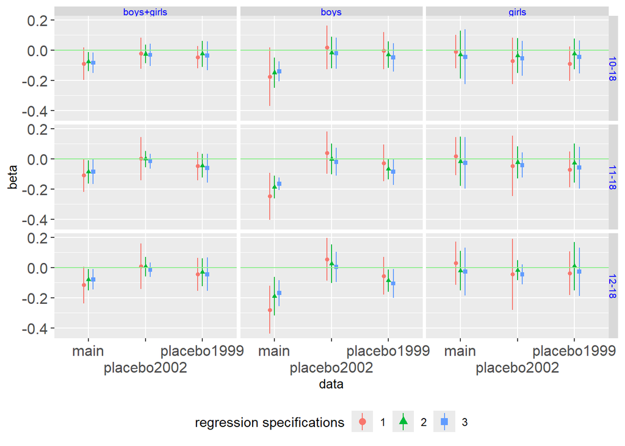

```r
#### results <- qread("../save/DID2024_MainResults.qs")
#### results <- qread("save/DID2024_MainResults.qs")
s <- de <- 1
j <- clnum <- 2
m <- 3
cis <- NULL
for (ii in 1:2) {
  jjmax <- 1
  if (ii == 2) jjmax <- 2
  for (jj in 1:jjmax) {
    for (ge in c(3, 1, 2)) {
      for (s in 1:3) {
        cis0 <- lapply(results[[ii]][[jj]][[s]][[j]][[ge]][[m]][[clnum]], "[[", "ci")
        cis0 <- lapply(cis0, data.table)
        cis0 <- lapply(cis0, function(x) x[, data := c("main", "placebo")[ii]])
        cis0 <- lapply(cis0, function(x) x[, cohort := c("1999", "2002")[jj]])
        cis0 <- lapply(cis0, function(x) x[, gender := genderitems[ge]])
        cis0 <- lapply(cis0, function(x) x[, ageLB := (10:12)[s]])
        cis0 <- lapply(1:length(cis0), function(i) cis0[[i]][, spec := i])
        cis0 <- rbindlist(cis0)
        cis <- rbindlist(list(cis, cis0))
      }
    }
  }
}
cis <- cis[grepl("^agHH.yr", Coef), ]
cis[, group := factor(paste0(data, cohort),
  levels = c("main1999", "placebo2002", "placebo1999"))]
cis[, group := factor(group, labels = c("main", "placebo2002", "placebo1999"))]
cis[, spec := factor(spec)]
cis[, yintercept := 0]
cis[, gender := factor(gender, levels = genderitems[c(3, 1, 2)])]
cis[, ageLB := factor(ageLB, labels = c("10-18", "11-18", "12-18"))]
library(ggplot2)
PointRange <-  geom_pointrange(aes(ymin = CI_L, ymax = CI_U),
    stat = "identity", fatten = 1.75,
    position = position_dodge(width = .25))
g <- ggplot(data = cis,
    aes(x = group, y = beta, group = spec, fill = spec, shape = spec, colour = spec)) +
  PointRange + ThisTheme + facet_grid(ageLB ~ gender) +
  xlab("data") +
  scale_x_discrete(guide = guide_axis(n.dodge = 2)) +
  labs(color  = "regression specifications", fill = "regression specifications",
    shape = "regression specifications") +
  ThisThemeEnd +
  guides(
    colour = guide_legend(title = "regression specifications", nrow = 1),
    fill = guide_legend(title = "regression specifications", nrow = 1),
    shape = guide_legend(title = "regression specifications", nrow = 1)
    ) +
  geom_hline(aes(yintercept = yintercept), colour = "lightgreen")
pdf(
  "../save/MainVsPlaceboPlotsByAgeLBByGender.pdf"
  , width = 2*12/2.54, height = 2*8/2.54)
print(g)
whatever <- dev.off()
pdf(
  "../draft/Figures/App_MainVsPlaceboPlotsByAgeLBByGender.pdf"
  , width = 2*12/2.54, height = 2*8/2.54)
print(g)
whatever <- dev.off()
rm(results)
```

- Verdict: Impacts found for boys of 11 years and older, even with raw DID.
  - AgHH definition: Head’s reply.
- Point estimates are larger for boys of higher age lowerbounds, indicating a brawn-based mechanism (Pitt, Rosenzweig, and Hassan 2012) at work.

  Pitt, Mark M., Mark R. Rosenzweig, and Mohammad Nazmul Hassan. 2012. “Human Capital Investment and the Gender Division of Labor in a Brawn-Based Economy.” *American Economic Review* 102 (7): 3531–60. https://doi.org/10.1257/aer.102.7.3531.
- Probably using 11-18 years old in the main estimation can give sharper results, but we need to commit to the original research design. Also, there is no good justification for using an *ad hoc* 11-18 age range.
- We need to refer to this figure in the main text that raw DID can show impacts.

## By age group

**Click here to see the code of results by school age group.**

```r
Res2 <- qread("../save/TabulatedMainResults2.qs")
NR2 <- qread("../save/TabulatedMainResultsNR2.qs")
Enr2 <- qread("../save/TabulatedMainResultsEnr2.qs")
#### Res2 <- qread("save/TabulatedMainResults2.qs")
#### NR2 <- qread("save/TabulatedMainResultsNR2.qs")
#### Enr2 <- qread("save/TabulatedMainResultsEnr2.qs")
Res2[, gender := factor(gender, levels = genderitems[c(3, 1, 2)])]
NR2[, gender := factor(gender, levels = genderitems[c(3, 1, 2)])]
Enr2[, gender := factor(gender, levels = genderitems[c(3, 1, 2)])]
aghh.defs2 <- aghh.defs[c(3, 2, 4, 1)]
Aghh.defs2 <- Aghh.defs[c(3, 2, 4, 1)]
Res2[, agdef := factor(agdef, levels = aghh.defs2)]
Res2[, Agdef := factor(agdef, labels = Aghh.defs2)]
Enr2[, agdef := factor(agdef, levels = aghh.defs2)]
Enr2[, Agdef := factor(agdef, labels = Aghh.defs2)]
NR2[, agdef := factor(agdef, levels = aghh.defs2)]
NR2[, Agdef := factor(agdef, labels = Aghh.defs2)]
res2 <- Res2[grepl("di", HHtype) & grepl("hd", agdef) & grepl("m.1", data)
   & grepl(2, agegroup) & !is.na(group), ]
nR <- NR2[grepl("hd", agdef) & grepl("m", data)
  & grepl("^B", inference) & grepl("di", HHtype) & grepl(2, agegroup), ]
enr0 <- unique(Enr2[grepl("hd", agdef) & grepl("m", data) & grepl(2, agegroup)
  & grepl("B", inference) & grepl("di", HHtype), ])
enr0[, EnRate := formatC(EnRate, digits = 4, format = "f")]
res2[, spec := factor(reg, labels = 1:3)]
res2[, Estimate := formatC(beta, digits = 4, format = "f")]
res2[, ci := paste0("\\mbox{\\tiny [",
  formatC(CI_L, digits = 2, format = "f"), ", ",
  formatC(CI_U, digits = 2, format = "f"), "]}")]
res2[grepl("^L", inference), ci := paste0("\\mbox{\\tiny (",
  formatC(CI_L, digits = 2, format = "f"), ", ",
  formatC(CI_U, digits = 2, format = "f"), ")}")]
setnames(res2, "p_val", "p")
res2[, pv := paste0("\\{", formatC(p*100, digits = 1, format = "f"), "\\}")]
res2[, se := paste0("(", formatC(SE, digits = 4, format = "f"), ")")]
AddStar <- T
if (AddStar) {
  res2[, est := Estimate]
  res2[, Estimate := paste0(est, "^{\\phantom{***}}")]
  res2[p < .1, Estimate := paste0(est, "^{*\\phantom{**}}")]
  res2[p < .05, Estimate := paste0(est, "^{**\\phantom{*}}")]
  res2[p < .01, Estimate := paste0(est, "^{***}")]
  res2[est > 0, Estimate := paste0("\\phantom{-}", Estimate)]
  res2[, est := NULL]
}
#### main/placebo results
options(width=120)
setorder(res2, gender, reg)
setorder(nR, gender)
setorder(enr0, gender)
#### tabulate by specification
for (s in c("pri", "sec")) {
  main <- rbind(
    res2[grepl(s, group) & grepl("^agH", Coef) & grepl("^B", inference), Estimate]
    ,
    res2[grepl(s, group) & grepl("^agH", Coef) & grepl("B", inference), se]
    ,
    res2[grepl(s, group) & grepl("^agH", Coef) & grepl("B", inference), pv]
    ,
    res2[grepl(s, group) & grepl("^agH", Coef) & grepl("B", inference), ci]
  )
  sib <-  rbind(
     res2[grepl(s, group) & grepl("SibF.*H.*yr", Coef) & grepl("BR", inference), Estimate]
     ,
     res2[grepl(s, group) & grepl("SibF.*H.*yr", Coef) & grepl("B", inference), se]
     ,
     res2[grepl(s, group) & grepl("SibF.*H.*yr", Coef) & grepl("B", inference), pv]
     ,
     res2[grepl(s, group) & grepl("SibF.*H.*yr", Coef) & grepl("B", inference), ci]
     ,
     res2[grepl(s, group) & grepl("SibM.*H.*yr", Coef) & grepl("BR", inference), Estimate]
     ,
     res2[grepl(s, group) & grepl("SibM.*H.*yr", Coef) & grepl("B", inference), se]
     ,
     res2[grepl(s, group) & grepl("SibM.*H.*yr", Coef) & grepl("B", inference), pv]
     ,
     res2[grepl(s, group) & grepl("SibM.*H.*yr", Coef) & grepl("B", inference), ci]
   )
  sib <- cbind("", "", sib[, 1], "", "", sib[, 2], "", "", sib[, 3])
  nr <- rbind(
    formatC(nR[grepl(s, group), ][order(gender, spec), R], digits = 4, format = "f")
  , formatC(nR[grepl(s, group), ][order(gender, spec), Yes], digits = 0, format = "f")
  , formatC(nR[grepl(s, group), ][order(gender, spec), n], digits = 0, format = "f")
  )
  nr <- data.table(nr)
  nr[2:3, c(1, 3, 4, 6, 7, 9) := ""]
  nr <- as.matrix(nr)
  enr <- matrix(
   enr0[grepl(s, group), ][order(gender, tee, agHH), EnRate]
   , byrow = F, nrow = 4)
  enr <- data.table(enr[, rep(1:3, each = 3)])
  enr[, c(1, 3, 4, 6, 7, 9) := ""]
  enr <- as.matrix(enr)
  main <- rbind(main, sib, nr, enr)
  assign(paste0("main", s), main)
}
mrtab <- rbind(mainpri, mainsec)
mrtab <- cbind(
    rep(c(
      "Agricultural household * year 2002",
      "\\hspace{1em} se",
      "\\hspace{1em} $p$ value",
      "\\hspace{1em} CI",
      "\\underline{\\phantom{mm}} * Older sisters",
      "\\hspace{1em} se",
      "\\hspace{1em} $p$ value",
      "\\hspace{1em} CI",
      "\\underline{\\phantom{mm}} * Older brothers",
      "\\hspace{1em} se",
      "\\hspace{1em} $p$ value",
      "\\hspace{1em} CI",
      "$\\bar{R}^{2}$", "N: Agricultural HHs", "N",
      paste0("Mean of ", rep(c("treated", "control"), 2), " in ",
        list(rep(c(1999, 2002), each = 2), rep(c(2002, 2006), each = 2))[[1]])
       ), 2
    ),
 mrtab)
#### LaTeX output
####allcovrows <- which(grepl("\\w", mrtab[, 1]) &
####  !grepl("trend|^N|^R2|\\\\bar\\{|Mea.*1999|Mea.*200|^\\\\hspace", mrtab[, 1]))
#### pval: change bracket to brace
####for (i in allcovrows+2) mrtab[i, ] <- gsub("\\((.*?)\\)", "\\\\{\\1\\\\}", mrtab[i, ])
SepCols <- c(3, 6)
ltb <- latextab(mrtab, delimiterline = NULL,
    hcenter = c(3, rep(1.3, ncol(mrtab)-1)),
    hleft = c("\\scriptsize", rep("\\hfil\\scriptsize$", ncol(mrtab)-1)),
    hright = c("\\hfill", rep("$", ncol(mrtab)-1)),
    headercolor = NULL,
    adjustlineskip = "-.5ex", adjlskiprows = grep("CI|.p. val", mrtab[, 1])-1,
    addseparatingcols = SepCols, separatingcolwidth = rep(.1, length(SepCols)),
    separatingcoltitle = c("\\textsf{Boys+Girls}", "\\textsf{Boys}", "\\textsf{Girls}")
  )
ltb <- c(
  ltb[1],
  "\\hline",
  ltb[2:grep("cline", ltb), ],
  "&\\multicolumn{11}{c}{\\scriptsize A. Primary school ages}\\\\",
  paste("&",
    gsub("6\\)", "6)&", gsub("3\\)", "3)&", paste(paste0("(", 1:9, ")", collapse = "&")))), "\\\\"),
  ltb[(grep("cline", ltb)+2):(grep("CI", ltb)[3]), ],
  paste("Demographic fixed trends",
    gsub("\\&$", "\\\\\\\\",
    paste(rep(paste(paste(rep("& \\mbox{\\scriptsize Yes}", 3), collapse = ""), "&"), 3), collapse = ""))
    ),
  paste("Other household fixed trends&",
    paste(rep(paste(rep("& \\mbox{\\scriptsize Yes}", 2), collapse = ""), 3), collapse = "&&"),
    "\\\\"),
  paste("Thana fixed trends&",
    paste(rep("&&\\mbox{\\scriptsize Yes}", 3), collapse = "&&"),
    "\\\\"),
  ltb[(grep("CI", ltb)[3]+1):(grep("M.*rol in 2", ltb)[1]), ],
  "&\\multicolumn{11}{c}{\\scriptsize B. Secodary school ages}\\\\",
  paste("&",
    gsub("5\\)", "5)&", gsub("2\\)", "2)&", paste(paste0("(", 1:9+9, ")", collapse = "&")))), "\\\\"),
  ltb[(grep("M.*rol in 2", ltb)[1]+1):(nrow(ltb)-1), ],
  "\\hline",
    ltb[nrow(ltb), ]
  )
ltb <- gsub("CI|.p. value| se ", "", ltb)
ltb <- gsub("(^\\\\cline.*$)", "\\1[-1ex]", ltb)
ltb <- gsub("household", "HH", ltb)
ltb <- gsub("Number of ol", "Ol", ltb)
N1 <- gsub("N.*?&", "", ltb[grepl("N: A", ltb)])
N1 <- gsub("\\\\", "", N1)
N1 <- gsub(" ", "", N1)
N1 <- unique(unlist(strsplit(N1, " ?\\& ?")))
N1 <- N1[nchar(N1)>0]
for (nn in 1:length(N1))
  ltb <- gsub(paste0(N1[nn], ".*\\& ", N1[nn], collapse = ""),
    paste("\\\\multicolumn{3}{c}{\\\\scriptsize", N1[nn], "}"), ltb)
N2 <- gsub("N *\\&", "", ltb[grepl("N *\\&", ltb)])
N2 <- gsub("\\\\", "", N2)
N2 <- gsub(" ", "", N2)
N2 <- unique(unlist(strsplit(N2, " ?\\& ?")))
N2 <- N2[nchar(N2)>0]
ltb[grep(N2[1], ltb)] <-
    paste("N", paste(
    paste("& \\multicolumn{3}{c}{\\scriptsize",  N2[1:3], "}")
    , collapse = "&"), "\\\\")
ltb[grep(N2[4], ltb)] <-
    paste("N", paste(
    paste("& \\multicolumn{3}{c}{\\scriptsize",  N2[3+1:3], "}")
    , collapse = "&"), "\\\\")
N3 <- gsub("Mean.*?\\&", "", ltb[grepl("Mean", ltb)])
N3 <- gsub("\\&", "", N3)
N3 <- gsub("\\\\\\\\", "", N3)
N3 <- strsplit(N3, " +")
N3 <- lapply(N3, unique)
N3 <- lapply(N3, function(x) x[nchar(x)>0])
for (mm in 1:8)
  for (nn in 1:3)
    ltb <- gsub(paste0(N3[[mm]][nn], ".*", N3[[mm]][nn], collapse = ""),
      paste("\\\\multicolumn{3}{c}{\\\\scriptsize", N3[[mm]][nn], "}"), ltb)
ltb <- ltb[!grepl("Raw", ltb)]
write.tablev(ltb
  ,  "../save/MainGenderAgeGroup2WithInteractionsResults.tex"
  ,  colnamestrue = F)
write.tablev(ltb
  ,  "../draft/Tables/App_MainGenderAgeGroup2WithInteractionsResults.tex"
  ,  colnamestrue = F)
#### for compact tables without triple interactions
ninter <- length(grep("Older", ltb))
ltb2 <- ltb[-(grep("Older", ltb)+rep(0:2, ninter))]
write.tablev(ltb2
  ,  "../save/MainGenderAgeGroup2Results.tex"
  ,  colnamestrue = F)
#### HTML outputs
mrtab <- rbind(mrtab,
  "Covariates, thana trends" = c("Covariates, thana trends", rep(c("", "Y", "Y"), 3)),
  "HH trends" = c("HH trends", rep(c("", "", "Y"), 3)))
Tab <- data.table(mrtab)
setnames(Tab, paste0("v", 1:ncol(Tab)))
aghhrows <- grep("^Ag", Tab[, v1])
nt <- ncol(Tab)-1
Tab <- rbind(t(c("", 1:nt)), Tab, use.names = F)
for (iii in 2:length(aghhrows)) {
  setnames(Tab, paste0("v", 1:ncol(Tab)))
  aghhrows <- grep("^Ag", Tab[, v1])
  Tab <- rbind(
    Tab[1:(aghhrows[iii]-1), ],
    t(c("", nt*(iii-1)+1:nt)),
    Tab[aghhrows[iii]:nrow(Tab), ], use.names = F)
}
setnames(Tab, c("variables", paste0("v", 1:nt)))
Tab <- lapply(Tab, function(x) gsub("\\\\mbox\\{\\\\tiny(.*)\\}", "\\1", x))
Tab <- lapply(Tab, function(x) gsub("\\^.*", "", x))
Tab <- lapply(Tab, function(x) gsub("\\\\phantom\\{-\\}", " ", x))
Tab <- lapply(Tab, function(x) gsub("\\\\hspace\\{.*\\}", " ", x))
Tab <- lapply(Tab, function(x) gsub(" *CI.*|.*p. value| +se", " ", x))
Tab <- lapply(Tab, function(x) gsub("\\\\underline\\{.*\\}", "____", x))
Tab <- lapply(Tab, function(x) gsub("^.*bar.R.*", "R2", x))
Tab <- lapply(Tab, function(x) gsub("\\\\phantom\\{.*?\\}", "", x))
Tab <- lapply(Tab, function(x) gsub("\\^\\{.*\\}", "", x))
Tab <- do.call(cbind, Tab)
colnames(Tab) <- c("variables", rep(c("raw DID", "+covariates",
  "+HH trends", "+HH*agHH fixed trends")[-4], 3))
Tab <- data.table(Tab)
#### pval: change bracket to brace
####allcovrows <- which(grepl("\\w", Tab[, variables]) &
####  !grepl("trend|^N|^R2|Mea.*1999|Mea.*200", Tab[, variables]))
####for (i in allcovrows+2) for (j in 2:ncol(Tab)) set(Tab, i, j, value = gsub("\\)", "\\}", Tab[[j]][i]))
####for (i in allcovrows+2) for (j in 2:ncol(Tab)) set(Tab, i, j, value = gsub("\\(", "\\{", Tab[[j]][i]))
bgcolor <- "#ffcc99"
kt <- kable(Tab, align = paste0("r", paste0(rep("c", ncol(Tab)-1), collapse = "")),
  row.names = F, caption =
  paste("Main results: Enrollment impacts for year 1999-2002 by school level,",
    "direct offspring, Satterthwaite correction"))
kt <- kable_styling(kt, full_width = F, position = "left", fixed_thead = T,
  html_font = "Cambria", bootstrap_options = c("condensed"))
kt <- add_header_above(kt, c(" " = 1, "Boys+girls" = 3, "Boys" = 3, "Girls" = 3),
  background = bgcolor)
kt <- row_spec(kt, 0, align = paste0(rep("c", ncol(Tab)-1), collapse = ""),
  background = bgcolor)
aghhrows <- grep("^Ag", Tab[, variables])
kt <- row_spec(kt, rep(aghhrows, each = plusrows+1)+0:plusrows,
  bold = F, color = "black", background = "#87cefa")
for (iii in 1:length(aghhrows))
  kt <- pack_rows(kt,
    group_label=c("A. Primary school ages", "B. Secondary school ages")[iii],
    aghhrows[iii]-1, aghhrows[iii]+(plusrows+1)*4)
allcovrows <- which(grepl("\\w", Tab[, variables]) &
  !grepl("trend|^N|^R2|Mea.*1999|Mea.*200", Tab[, variables]))
kt <- row_spec(kt, allcovrows+plusrows, font_size = 11)
kt <- pack_rows(kt, group_label="Common specifications",
  grep("^Cov.*tr", Tab[, variables]), grep("^HH", Tab[, variables]))
kt <- column_spec(kt, 1, width = "6.25cm; min-width:6.25cm;")
kt <- column_spec(kt, 2:10, width = "2.25cm; min-width:2.25cm;")
kt <- scroll_box(kt, height = "800px")
kt <- footnote(kt,
           general = "Sample of direct offspring of household heads. ",
           number = c(SpecMemo1html, SEMemoForSelectedResultsNoStarhtml)
           )
```

```r
ii <- jj <- s <- 1
assign(paste0(c("M", "P")[ii], c(9, 2)[jj], (10:12)[s], "AgeGroup2"), mrtab)
assign(paste0(c("M", "P")[ii], c(9, 2)[jj], (10:12)[s], "AgeGroup2H"), kt)
qsave(kt, paste0("../save/", c("M", "P")[ii], c(9, 2)[jj], (10:12)[s], "AgeGroup2H.qs"))
```

```r
library(ggplot2)
Res2 <- qread("../save/TabulatedMainResults2.qs")
Res2[, gender := factor(gender, levels = genderitems[c(3, 1, 2)])]
mbga <- Res2[grepl("di", HHtype) & grepl("hd", agdef) & grepl("^agHH.yr2$", Coef)
  & grepl("pri|sec", group), ]
mbga[, spec := factor(reg, labels = 1:3)]
mbga[, spec := factor(reg, labels = 1:3)]
PointRange <-  geom_pointrange(aes(ymin = CI_L, ymax = CI_U),
    stat = "identity", fatten = 1.75,
    position = position_dodge(width = .25))
g <- ggplot(data = mbga[grepl("A.*2", agegroup) & !is.na(group), ],
    aes(x = group, y = beta, group = spec, fill = spec, shape = spec, colour = spec)) +
  PointRange + ThisTheme + facet_grid( ~ gender) +
  xlab("age groups") +
  labs(color  = "regression specifications", fill = "regression specifications",
    shape = "regression specifications") +
  ThisThemeEnd +
  guides(
    colour = guide_legend(title = "regression specifications", nrow = 1),
    fill = guide_legend(title = "regression specifications", nrow = 1),
    shape = guide_legend(title = "regression specifications", nrow = 1)
    ) +
  geom_hline(aes(yintercept = yintercept), colour = "lightgreen")
pdf(
  "../save/GenderAgeGroup2Impacts.pdf"
  , width = 2*12/2.54, height = 2*8/2.54)
print(g)
whatever <- dev.off()
pdf(
  "../draft/Figures/GenderAgeGroup2Impacts.pdf"
  , width = 2*12/2.54, height = 2*8/2.54)
print(g)
whatever <- dev.off()
```

Main results: Enrollment impacts for year 1999-2002 by school level, direct offspring, Satterthwaite correction

[output not shown]

Note:  
Sample of direct offspring of household heads.  
<sup>1</sup> Agricultural households * year 2002 is an interaction term of agricultural household dummy and year 2002 dummy. All the interaction terms are demeaned. For each panel, first columns are raw DID. Second columns add time-varying thana level characteristics (yield, mean rainfall, mean high temperature, mean low temperature), time-varying individual level characteristics (age squared, recipient of a poverty program), and Thana trends that are interactions of year 2002 dummy with Thana fixed effects. Third columns add interactions of year 2002 dummy and baseline individual level characterstics (sex of individual, household head’s and spouse’s education, number of older male/female siblings, per member land holding, per member non-land asset holding, piped water access, structured toilet access) $\bfx_{i}r_{t}$, and triple interactions of year 2002 dummy, individual characteristics, and agricultural household dummy $\bfx_{i}r_{t}D_{i}$. Rows of $\underline{\phantom{mm}}*x$ show estimates of the triple interaction term of $x_{i}$, or $x_{i}r_{t}D_{i}$. Regressions include all the linear terms of each interactions and all the double interaction terms of each triple interactions. Parental education variables are strongly collinear with agricultural household dummy and are used only in year 2002 interaction terms to avoid multicollinearity.  
<sup>2</sup> Standard errors in the parentheses are clusterd at thana level with a correction for small number of clusters using bias reduced linearization (Satterthwaite correction). $P$ values in percentages are shown in braces. 95% confidence intervals are shown in square brackets.

Results by school level and gender

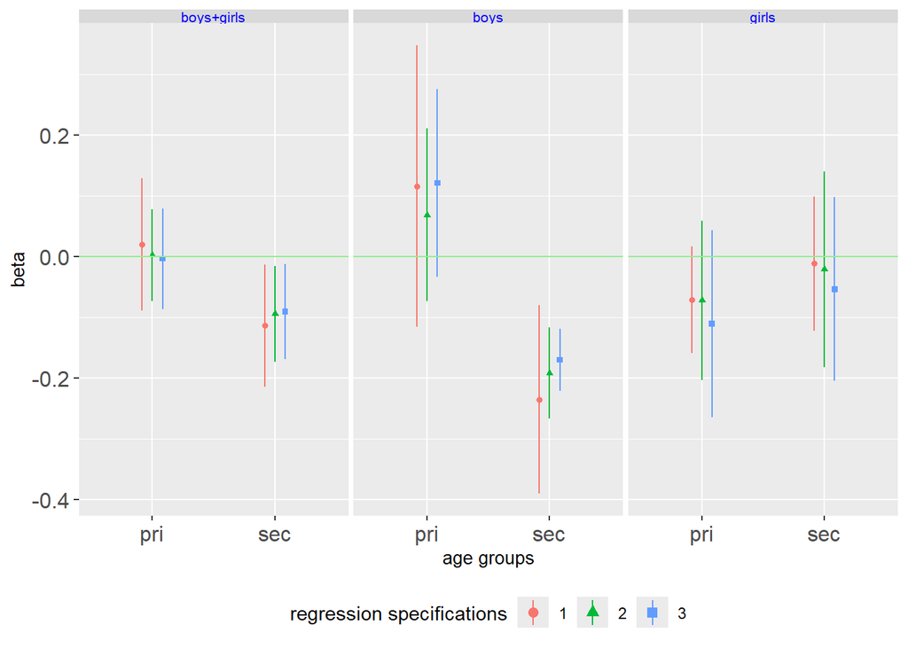

## Other schooling outcomes: Grade progression and days absent per month

- Students enrolled in 1999: Baseline sample including dropped out individuals.
- Students enrolled in 1999 and 2002 = Students enrolled in 1999 - dropped out individuals

Boys+girls and boys and girls subsamples.

**Click here to see the code of num grades days absent, full results.**

```r
#### HTML output
library(kableExtra)
Tab <- TabGD
#### Tab <- MNDbg
colnames(Tab) <- c("variables", rep(c("raw DID", "+covariates", "+HH trends"), 3))
Tab[, 1] <- gsub("CI\\$.*\\$", "", Tab[, 1])
Tab[, 1] <- gsub("p\\$.*\\$", "", Tab[, 1])
Tab[, 1] <- gsub("se\\$.*\\$", "", Tab[, 1])
Tab[, 1] <- gsub("(^\\\\cline.*$)", "\\1[-1ex]", Tab[, 1])
Tab[, 1] <- gsub("household", "HH", Tab[, 1])
Tab[, 1] <- gsub("\\\\hspace\\{.*\\}", "", Tab[, 1])
Tab[, 1] <- Tab[, 1][!grepl("Raw", Tab[, 1])]
for (iii in 2:ncol(Tab)) {
  Tab[, iii] <- gsub("\\\\mbox\\{\\\\tiny ?(.*)\\}", "\\1", Tab[, iii])
  Tab[, iii] <- gsub("\\\\phantom\\{.*?\\}", "", Tab[, iii])
  Tab[, iii] <- gsub("\\^\\{(.*)\\}", "", Tab[, iii])
}
if (any(is.na(Tab))) Tab[is.na(Tab)] <- ""
bgcolor <- "#ffcc99"
Tab <- data.table(Tab)
kt <- kable(Tab, align = paste0("r", paste0(rep("c", ncol(Tab)-1), collapse = "")),
  caption =
  "Other outcome impacts: 10-18 years old, direct offspring, Satterthwaite correction")
####kt <- add_header_above(kt, c(" " = 1, "Grade progression" = 3, "Days absent" = 3),
####  background = bgcolor)
kt <- add_header_above(kt, c(" " = 1, "Boys+girls" = 3, "Boys" = 3, "Girls" = 3),
  background = bgcolor)
allcovrows <- which(grepl("\\w", Tab[, variables]) &
  !grepl("trend|^N$|^N:|^R2|200|199", Tab[, variables]))
kt <- row_spec(kt, allcovrows+plusrows, font_size = 11)
kt <- row_spec(kt, 0, align = paste0(rep("c", ncol(Tab)), collapse = ""),
  background = bgcolor)
aghhrows <- grep("Agri", Tab[, variables])
kt <- row_spec(kt,
  rep(aghhrows, each = plusrows+1)+rep(0:plusrows, length(aghhrows)),
  bold = F, color = "black", background = "#87cefa")
kt <- column_spec(kt, 1, width = "6cm; min-width:6cm;")
kt <- column_spec(kt, 2:10, width = "2.25cm; min-width:2.25cm;")
RowGenderGroupCSS <- "background-color: #666; color: #fff;"
kt <- pack_rows(kt, group_label="Number of grades",
  aghhrows[1]-1, aghhrows[3]-1,
  label_row_css = RowGenderGroupCSS)
kt <- pack_rows(kt, group_label="Days absent",
  aghhrows[3]-1, aghhrows[length(aghhrows)-2]-1,
  label_row_css = RowGenderGroupCSS)
kt <- pack_rows(kt, group_label="Number of grades, placebo estimation",
  aghhrows[length(aghhrows)-1]-1, aghhrows[length(aghhrows)]-1,
  label_row_css = RowGenderGroupCSS)
packrowtext <- c(
  "Students enrolled in 1999",
  "Students enrolled in 1999 and 2002",
  "Students enrolled in 1999 and 2002",
  "Students enrolled in 1999, cross section OLS of 2000",
  "Students enrolled in 2002, cross section OLS of 2003",
  "Students enrolled in 1999 and 2002, cross section OLS of 2000",
  "Students enrolled in 1999 and 2002, cross section OLS of 2003",
  "Students of 10-18 in 2002, 2002-2006 placebo impacts")
for (iii in 1:length(packrowtext))
  kt <- pack_rows(kt, group_label=packrowtext[iii],
  aghhrows[iii]-1, aghhrows[iii+1]-1)
kt <- pack_rows(kt, group_label="Students of 10-18 in 1999, 2002-2006 placebo impacts",
  aghhrows[length(packrowtext)+1]-1, grep("Cov.*ana", Tab[, variables])-1)
kt <- pack_rows(kt, group_label="Common specifications",
  grep("Cov.*ana", Tab[, variables]), grep("HH tr", Tab[, variables]))
kt <- scroll_box(kt, height = "800px")
kt <- footnote(kt,
           general = "Sample of direct offspring of household heads. ",
           number = c(SpecMemo1, SEMemoForSelectedResultsNoStarhtml)
           )
```

Other outcome impacts: 10-18 years old, direct offspring, Satterthwaite correction

| variables | Boys+girls raw DID | Boys+girls +covariates | Boys+girls +HH trends | Boys raw DID | Boys +covariates | Boys +HH trends | Girls raw DID | Girls +covariates | Girls +HH trends |
| --- | --- | --- | --- | --- | --- | --- | --- | --- | --- |
| **Number of grades** |  |  |  |  |  |  |  |  |  |
| **Students enrolled in 1999** |  |  |  |  |  |  |  |  |  |
|  | 1 | 2 | 3 | 4 | 5 | 6 | 7 | 8 | 9 |
| Agricultural HH | -0.443 | -0.464 | -0.471 | -0.664 | -0.680 | -0.631 | -0.197 | -0.318 | -0.328 |
|  | (0.107) | (0.125) | (0.136) | (0.258) | (0.335) | (0.356) | (0.304) | (0.265) | (0.295) |
|  | {0.5} | {1.1} | {1.4} | {4.0} | {9.5} | {13.4} | {54.0} | {27.6} | {30.8} |
|  | [-0.700, -0.186] | [-0.774, -0.153] | [-0.805, -0.137] | [-1.287, -0.042] | [-1.528, 0.168] | [-1.535, 0.272] | [-0.930, 0.537] | [-0.970, 0.333] | [-1.047, 0.391] |
| Stipend program |  | 1.001 | 1.074 |  | -0.302 | -0.398 |  | 1.359 | 1.434 |
|  |  | (0.179) | (0.174) |  | (0.506) | (0.577) |  | (0.262) | (0.179) |
|  |  | {0.1} | {0.1} |  | {59.2} | {53.4} |  | {0.2} | {0.0} |
|  |  | [0.572, 1.430] | [0.647, 1.501] |  | [-1.900, 1.295] | [-2.105, 1.309] |  | [0.724, 1.994] | [1.002, 1.866] |
| Non-stipend program |  | 1.069 | 1.206 |  | -0.260 | -0.239 |  | 1.516 | 1.579 |
|  |  | (0.224) | (0.236) |  | (0.715) | (0.790) |  | (0.187) | (0.128) |
|  |  | {0.2} | {0.2} |  | {73.6} | {77.8} |  | {0.0} | {0.0} |
|  |  | [0.531, 1.607] | [0.637, 1.775] |  | [-2.351, 1.830] | [-2.434, 1.956] |  | [1.066, 1.966] | [1.272, 1.885] |
| R2 | 0.0251 | 0.2614 | 0.2942 | 0.0521 | 0.1829 | 0.2567 | 0.0055 | 0.4002 | 0.4449 |
| N: agHH |  | 210 |  |  | 105 |  |  | 105 |  |
| N |  | 393 |  |  | 181 |  |  | 212 |  |
| Mean of control in 1999 |  | 5.1585 |  |  | 5.1184 |  |  | 5.1869 |  |
| Mean of treated in 1999 |  | 5.0476 |  |  | 5.1619 |  |  | 4.9333 |  |
| Mean of control in 2002 |  | 7.2732 |  |  | 7.1447 |  |  | 7.3645 |  |
| Mean of treated in 2002 |  | 6.7190 |  |  | 6.5238 |  |  | 6.9143 |  |
| **Students enrolled in 1999 and 2002** |  |  |  |  |  |  |  |  |  |
|  | 10 | 11 | 12 | 13 | 14 | 15 | 16 | 17 | 18 |
| Agricultural HH | -0.189 | -0.231 | -0.269 | -0.256 | -0.215 | -0.114 | -0.167 | -0.238 | -0.229 |
|  | (0.097) | (0.119) | (0.077) | (0.302) | (0.387) | (0.483) | (0.228) | (0.228) | (0.330) |
|  | {9.6} | {10.2} | {1.3} | {42.8} | {60.3} | {82.4} | {49.2} | {33.6} | {51.2} |
|  | [-0.422, 0.044] | [-0.523, 0.062] | [-0.456, -0.081] | [-0.994, 0.482] | [-1.213, 0.784] | [-1.364, 1.137] | [-0.721, 0.387] | [-0.794, 0.319] | [-1.031, 0.572] |
| Stipend program |  | 0.696 | 0.854 |  | -0.116 | -0.110 |  | 1.195 | 1.294 |
|  |  | (0.222) | (0.183) |  | (0.577) | (0.747) |  | (0.297) | (0.299) |

[output cut: 125 more lines]

Note:  
Sample of direct offspring of household heads.  
<sup>1</sup> is an interaction term of agricultural household dummy and year 2002 dummy. All the interaction terms are demeaned. For each panel, first columns are raw DID. Second columns add time-varying thana level characteristics (yield, mean rainfall, mean high temperature, mean low temperature), time-varying individual level characteristics (age squared, recipient of a poverty program), and that are interactions of year 2002 dummy with Thana fixed effects. Third columns add interactions of year 2002 dummy and baseline individual level characterstics (sex of individual, household head’s and spouse’s education, number of older male/female siblings, per member land holding, per member non-land asset holding, piped water access, structured toilet access) $\bfx_{i}r_{t}$, and triple interactions of year 2002 dummy, individual characteristics, and agricultural household dummy $\bfx_{i}r_{t}D_{i}$. Rows of $\underline{\phantom{mm}}*x$ show estimates of the triple interaction term of $x_{i}$, or $x_{i}r_{t}D_{i}$. Regressions include all the linear terms of each interactions and all the double interaction terms of each triple interactions. Parental education variables are strongly collinear with agricultural household dummy and are used only in year 2002 interaction terms to avoid multicollinearity.  
<sup>2</sup> Standard errors in the parentheses are clusterd at thana level with a correction for small number of clusters using bias reduced linearization (Satterthwaite correction). $P$ values in percentages are shown in braces. 95% confidence intervals are shown in square brackets.

**Click here to see the R script of plotting effects on grade progression and days absent.**

```r
resultsG <- qread("../save/DID2024_NumGradesEnrollersGenderResults.qs")
resultsD <- qread("../save/DID2024_DaysAbsentEnrollersGenderResults.qs")
resultsC <- qread("../save/DID2024_DaysAbsentCrossSectionResults.qs")
```

These are produced in the section: Other schooling outcomes.

Number of grades impacts are estimated using both the main and placebo samples:

- DID estimates on incomplete panel portion.
- DID estimates on complete panel portion.

Days absent impacts are estimated using the main sample:

- DID estimates on complete panel portion.
- OLS estimates for 2003 impacts on 2003 enrollers.
- OLS estimates for 2000 impacts on 2000 enrollers.
- Placebo sample was not used because the 2006 data do not have the days absent information.

```
       Coef       beta   spec     gender       filesShort outcome               type
     <char>      <num> <fctr>     <fctr>           <fctr>  <char>             <fctr>
1: agHH.yr2 -0.4638553      2 boys+girls   1999 enrollers  Grades baseline enrollers
2: agHH.yr2 -0.4710013      3 boys+girls   1999 enrollers  Grades baseline enrollers
3: agHH.yr2 -0.2305532      2 boys+girls always enrollers  Grades   always enrollers
4: agHH.yr2 -0.2685877      3 boys+girls always enrollers  Grades   always enrollers
```

```
        Coef        beta   spec gender                         year       filesShort outcome               type
      <char>       <num> <fctr> <fctr>                       <fctr>           <fctr>  <char>             <fctr>
 1: agHH.yr2  0.11752137      1  girls Days absent\npanel 1999-2002 always enrollers    Days   always enrollers
 2: agHH.yr2  0.47424141      2  girls Days absent\npanel 1999-2002 always enrollers    Days   always enrollers
 3: agHH.yr2  0.28221994      3  girls Days absent\npanel 1999-2002 always enrollers    Days   always enrollers
 4:     agHH  0.09860652      1  girls        Days absent\nOLS 1999   curr enrollers    Days baseline enrollers
 5:     agHH -0.16397046      2  girls        Days absent\nOLS 1999   curr enrollers    Days baseline enrollers
 6:     agHH -0.24162316      3  girls        Days absent\nOLS 1999   curr enrollers    Days baseline enrollers
 7:     agHH  0.34313272      1  girls        Days absent\nOLS 2002   curr enrollers    Days baseline enrollers
 8:     agHH  0.18291994      2  girls        Days absent\nOLS 2002   curr enrollers    Days baseline enrollers
 9:     agHH -0.15439543      3  girls        Days absent\nOLS 2002   curr enrollers    Days baseline enrollers
10:     agHH -0.04700855      1  girls        Days absent\nOLS 1999 always enrollers    Days   always enrollers
11:     agHH -0.41644836      2  girls        Days absent\nOLS 1999 always enrollers    Days   always enrollers
12:     agHH -0.75217481      3  girls        Days absent\nOLS 1999 always enrollers    Days   always enrollers
13:     agHH  0.07051282      1  girls        Days absent\nOLS 2002 always enrollers    Days   always enrollers
14:     agHH  0.13095782      2  girls        Days absent\nOLS 2002 always enrollers    Days   always enrollers
15:     agHH -0.20081326      3  girls        Days absent\nOLS 2002 always enrollers    Days   always enrollers
```

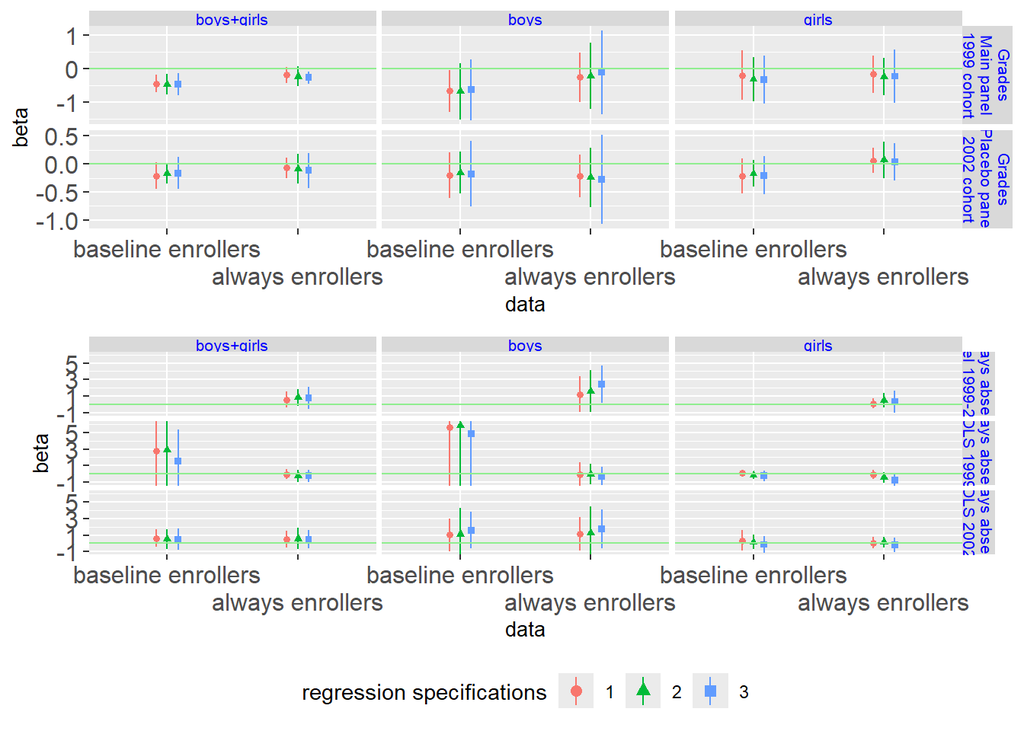

Grade progression, days absent by different subsamples

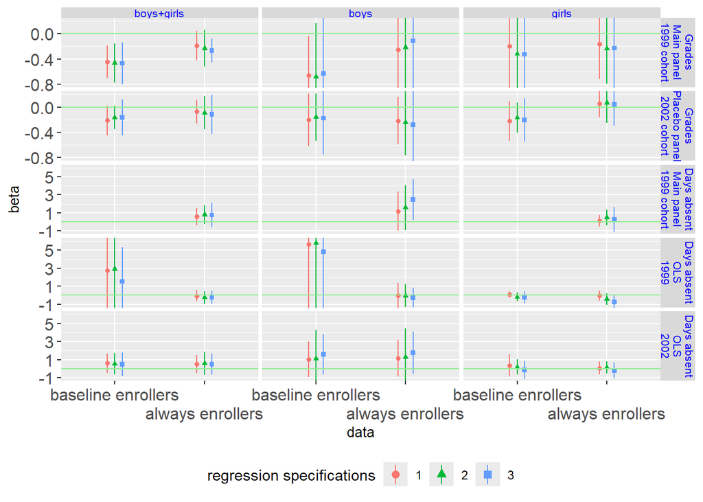

See estimation code of other schooling outcomes.

- Grade progreesion and days absent impacts are consistent with main results.
- Grade progression = 3 if progressed without a delay. Less than 3 indicates repetition or dropping out. When a student discontinues schooling, we use “the highest grade completed” observed in the latest round of the survey and compute the number of grades progressed.
- Using the baseline enroller sample (top panel), grade progression impact estimates are negative. Exam-harvest overlap delays progression by about .47 years (boys+girls, 5.64 months). Impacts on boys are larger in magnitude yet the sample size is too small.
  - Sample size is small as we must condition on children who are enrolled in 1999. Sample size of always enrollers is even smaller.
  - Always enroller sample gives larger $p$ values due mostly to weaker impacts.
  - Always enroller sample has weaker negative grade progression impacts because they are still enrolled.
- One year impact: As the calendar was favorable in 1999-2001, we consider these estimates as a one year impact because the negative effects were realised only in the academic year of 2002 which were captured in the survey in 2003.
- What this means: Even when the children of agricultural households are not dropping out of school, more than 40% of them lag behind in one grade progression relative to the children of non-agricultural households.
- Stipend and non-stipend programs help increase the progression for 1.3-1.5 year in a three year period among girls, but not among boys.
- Absence impacts are not detected, yet the point estimates are all positive, ranging from .1 to 2.4 days per month.
- Absence point estimates are larger among boys than girls, which is consistent with the brawn-based interpretation of main estimates.
- One possible reason for the small magnitude on days absent is attenuation. This variable reports a three month recall, so the interview dates for some households may be off harvesting periods, therefore it may contain measurement errors.
- Stipend and non-stipend programs help reduce the absence for 4-6 days per month among boys, but not among girls.
- For programs, boys respond in terms of daily attendance/absence, but not in terms of progression. Opposite is true for girls.
- Stipend and non-stipend programs may improve grade progression among girls, and they may improve daily attendance among boys. Girls may attend schools constantly with or without them because they are less engaged in remunerative work. Lower opportunity costs of schooling among girls may also allow a stronger responce to programs in terms of progression. It is unclear why they only affect atendance but not progression among boys.
- Placebo estimation of grade progression among “baseline enrollers of 2002” uses the 2002 cohort and measures impacts of 4 years between 2002-2006. It shows the children from agricultural households tend to progress more slowly by 0.04, 0.06 year per annum (0.51, 0.66 months), which are roughly 10% the size of 1999 impacts, although the $p$ values for placebo estimation are around 7% and are not as small as the 1999 impact estimates. On net, harvest-exam overlap may slow the grade progrssion by 0.42 year per annum (4.98 months).
- Placebo estimation of grade progression among “baseline enrollers of 1999” uses the 1999 cohort and shows statistically zero impacts, consistent with our maintained hypothesis.

## Placebo

### By gender and by aghh def

2002 cohort

| variables | Boys+girls raw DID | Boys+girls +covariates | Boys+girls +HH trends | Boys raw DID | Boys +covariates | Boys +HH trends | Girls raw DID | Girls +covariates | Girls +HH trends |
| --- | --- | --- | --- | --- | --- | --- | --- | --- | --- |
| **Head’s reply** |  |  |  |  |  |  |  |  |  |
|  | 1 | 2 | 3 | 4 | 5 | 6 | 7 | 8 | 9 |
| Agricultural household * year 2002 | -0.0477 | -0.0229 | -0.0367 | -0.0036 | -0.0271 | -0.0455 | -0.0900 | -0.0291 | -0.0494 |
|  | (0.031) | (0.034) | (0.037) | (0.052) | (0.037) | (0.039) | (0.048) | (0.037) | (0.039) |
|  | {16.8} | {53.0} | {35.5} | {94.6} | {48.6} | {29.0} | {10.3} | {46.2} | {25.3} |
|  | [-0.121, 0.026] | [-0.105, 0.060] | [-0.125, 0.052] | [-0.127, 0.120] | [-0.115, 0.061] | [-0.140, 0.049] | [-0.204, 0.024] | [-0.119, 0.060] | [-0.144, 0.045] |
| ____ * Older sisters |  |  | -0.0728 |  |  | -0.1016 |  |  | -0.0457 |
|  |  |  | (0.037) |  |  | (0.053) |  |  | (0.036) |
|  |  |  | {10.4} |  |  | {10.7} |  |  | {26.4} |
|  |  |  | [-0.167, 0.021] |  |  | [-0.234, 0.031] |  |  | [-0.140, 0.048] |
| ____ * Older brothers |  |  | 0.0033 |  |  | 0.0424 |  |  | -0.0402 |
|  |  |  | (0.037) |  |  | (0.053) |  |  | (0.047) |
|  |  |  | {93.2} |  |  | {45.2} |  |  | {42.2} |
|  |  |  | [-0.086, 0.093] |  |  | [-0.087, 0.172] |  |  | [-0.155, 0.074] |
| R2 | 0.0025 | 0.2019 | 0.2197 | 0.0000 | 0.1128 | 0.1631 | 0.0086 | 0.3399 | 0.3688 |
| N: Agricultural HHs |  | 440 |  |  | 217 |  |  | 223 |  |
| N |  | 812 |  |  | 386 |  |  | 426 |  |
| Mean of control in 2002 |  | 0.6747 |  |  | 0.6331 |  |  | 0.7094 |  |
| Mean of treated in 2002 |  | 0.5932 |  |  | 0.5438 |  |  | 0.6413 |  |
| Mean of control in 2006 |  | 0.4247 |  |  | 0.3787 |  |  | 0.4631 |  |
| Mean of treated in 2006 |  | 0.2955 |  |  | 0.2857 |  |  | 0.3049 |  |
| **Income source** |  |  |  |  |  |  |  |  |  |
|  | 10 | 11 | 12 | 13 | 14 | 15 | 16 | 17 | 18 |
| Agricultural household * year 2002 | -0.0461 | -0.0262 | -0.0392 | 0.0130 | -0.0010 | -0.0128 | -0.1020 | -0.0479 | -0.0674 |
|  | (0.032) | (0.032) | (0.037) | (0.051) | (0.043) | (0.038) | (0.049) | (0.032) | (0.048) |
|  | {19.3} | {43.8} | {32.5} | {80.6} | {98.1} | {74.6} | {7.6} | {18.1} | {20.6} |
|  | [-0.122, 0.030] | [-0.102, 0.050] | [-0.128, 0.049] | [-0.108, 0.134] | [-0.104, 0.102] | [-0.105, 0.079] | [-0.218, 0.014] | [-0.125, 0.029] | [-0.183, 0.048] |
| ____ * Older sisters |  |  | -0.0700 |  |  | -0.1195 |  |  | -0.0291 |
|  |  |  | (0.034) |  |  | (0.056) |  |  | (0.038) |
|  |  |  | {9.6} |  |  | {8.3} |  |  | {48.1} |

[output cut: 57 more lines]

Note:  
Sample of direct offspring of household heads.  
<sup>1</sup> Agricultural households * year 2002 is an interaction term of agricultural household dummy and year 2002 dummy. All the interaction terms are demeaned. For each panel, first columns are raw DID. Second columns add time-varying thana level characteristics (yield, mean rainfall, mean high temperature, mean low temperature), time-varying individual level characteristics (age squared, recipient of a poverty program), and Thana trends that are interactions of year 2002 dummy with Thana fixed effects. Third columns add interactions of year 2002 dummy and baseline individual level characterstics (sex of individual, household head’s and spouse’s education, number of older male/female siblings, per member land holding, per member non-land asset holding, piped water access, structured toilet access) $\bfx_{i}r_{t}$, and triple interactions of year 2002 dummy, individual characteristics, and agricultural household dummy $\bfx_{i}r_{t}D_{i}$. Rows of $\underline{\phantom{mm}}*x$ show estimates of the triple interaction term of $x_{i}$, or $x_{i}r_{t}D_{i}$. Regressions include all the linear terms of each interactions and all the double interaction terms of each triple interactions. Parental education variables are strongly collinear with agricultural household dummy and are used only in year 2002 interaction terms to avoid multicollinearity.  
<sup>2</sup> Standard errors in the parentheses are clusterd at thana level with a correction for small number of clusters using bias reduced linearization (Satterthwaite correction). $P$ values in percentages are shown in braces. 95% confidence intervals are shown in square brackets. $*$, $**$, $***$ indicate significance levels at 10%, 5%, 1% under BRL cluster robust standard errors, respectively.

1999 cohort

| variables | Boys+girls raw DID | Boys+girls +covariates | Boys+girls +HH trends | Boys raw DID | Boys +covariates | Boys +HH trends | Girls raw DID | Girls +covariates | Girls +HH trends |
| --- | --- | --- | --- | --- | --- | --- | --- | --- | --- |
| **Head’s reply** |  |  |  |  |  |  |  |  |  |
|  | 1 | 2 | 3 | 4 | 5 | 6 | 7 | 8 | 9 |
| Agricultural household * year 2002 | -0.0216 | -0.0278 | -0.0342 | 0.0192 | -0.0112 | -0.0170 | -0.0703 | -0.0471 | -0.0664 |
|  | (0.043) | (0.029) | (0.031) | (0.061) | (0.047) | (0.046) | (0.064) | (0.042) | (0.045) |
|  | {63.3} | {37.9} | {31.4} | {76.1} | {81.7} | {72.4} | {31.1} | {31.0} | {19.0} |
|  | [-0.125, 0.082] | [-0.099, 0.043] | [-0.110, 0.041] | [-0.126, 0.164] | [-0.123, 0.100] | [-0.129, 0.095] | [-0.224, 0.084] | [-0.151, 0.057] | [-0.177, 0.044] |
| ____ * Older sisters |  |  | -0.0699 |  |  | -0.0059 |  |  | -0.0812 |
|  |  |  | (0.042) |  |  | (0.045) |  |  | (0.082) |
|  |  |  | {16.0} |  |  | {90.0} |  |  | {37.1} |
|  |  |  | [-0.180, 0.040] |  |  | [-0.121, 0.109] |  |  | [-0.299, 0.137] |
| ____ * Older brothers |  |  | -0.0093 |  |  | 0.0020 |  |  | -0.0436 |
|  |  |  | (0.052) |  |  | (0.076) |  |  | (0.055) |
|  |  |  | {86.6} |  |  | {98.0} |  |  | {46.0} |
|  |  |  | [-0.140, 0.121] |  |  | [-0.191, 0.195] |  |  | [-0.182, 0.094] |
| R2 | 0.0005 | 0.2928 | 0.3199 | 0.0005 | 0.1052 | 0.1515 | 0.0054 | 0.4885 | 0.5218 |
| N: Agricultural HHs |  | 341 |  |  | 176 |  |  | 165 |  |
| N |  | 616 |  |  | 304 |  |  | 312 |  |
| Mean of control in 2002 |  | 0.4909 |  |  | 0.4453 |  |  | 0.5306 |  |
| Mean of treated in 2002 |  | 0.3783 |  |  | 0.2898 |  |  | 0.4727 |  |
| Mean of control in 2006 |  | 0.2691 |  |  | 0.2500 |  |  | 0.2857 |  |
| Mean of treated in 2006 |  | 0.1349 |  |  | 0.1136 |  |  | 0.1576 |  |
| **Income source** |  |  |  |  |  |  |  |  |  |
|  | 10 | 11 | 12 | 13 | 14 | 15 | 16 | 17 | 18 |
| Agricultural household * year 2002 | -0.0067 | -0.0202 | -0.0177 | 0.0506 | 0.0349 | 0.0303 | -0.0760 | -0.0581 | -0.0702 |
|  | (0.052) | (0.026) | (0.034) | (0.063) | (0.054) | (0.052) | (0.073) | (0.044) | (0.054) |
|  | {90.0} | {46.8} | {62.3} | {44.9} | {54.3} | {58.3} | {33.8} | {23.4} | {24.3} |
|  | [-0.130, 0.117] | [-0.084, 0.043] | [-0.101, 0.066] | [-0.101, 0.202] | [-0.096, 0.166] | [-0.099, 0.159] | [-0.253, 0.101] | [-0.165, 0.049] | [-0.204, 0.063] |
| ____ * Older sisters |  |  | -0.0585 |  |  | -0.0046 |  |  | -0.0781 |
|  |  |  | (0.050) |  |  | (0.067) |  |  | (0.076) |
|  |  |  | {30.3} |  |  | {94.8} |  |  | {35.6} |

[output cut: 57 more lines]

Note:  
Sample of direct offspring of household heads.  
<sup>1</sup> Agricultural households * year 2002 is an interaction term of agricultural household dummy and year 2002 dummy. All the interaction terms are demeaned. For each panel, first columns are raw DID. Second columns add time-varying thana level characteristics (yield, mean rainfall, mean high temperature, mean low temperature), time-varying individual level characteristics (age squared, recipient of a poverty program), and Thana trends that are interactions of year 2002 dummy with Thana fixed effects. Third columns add interactions of year 2002 dummy and baseline individual level characterstics (sex of individual, household head’s and spouse’s education, number of older male/female siblings, per member land holding, per member non-land asset holding, piped water access, structured toilet access) $\bfx_{i}r_{t}$, and triple interactions of year 2002 dummy, individual characteristics, and agricultural household dummy $\bfx_{i}r_{t}D_{i}$. Rows of $\underline{\phantom{mm}}*x$ show estimates of the triple interaction term of $x_{i}$, or $x_{i}r_{t}D_{i}$. Regressions include all the linear terms of each interactions and all the double interaction terms of each triple interactions. Parental education variables are strongly collinear with agricultural household dummy and are used only in year 2002 interaction terms to avoid multicollinearity.  
<sup>2</sup> Standard errors in the parentheses are clusterd at thana level with a correction for small number of clusters using bias reduced linearization (Satterthwaite correction). $P$ values in percentages are shown in braces. 95% confidence intervals are shown in square brackets. $*$, $**$, $***$ indicate significance levels at 10%, 5%, 1% under BRL cluster robust standard errors, respectively.

## Attrition

**Click here to see the R script of attrition analysis.**

```r
library(clubSandwich)
pathsource00 <- paste0(pathsource, "/ffe/2000/Data/HouseholdData/STATA/")
fn <- list.files(pathsource00)
fn0 <- list.files(pathsource00, full.names = T)
pathsource03 <- paste0(pathsource, "/ffe/2003/Data/HouseholdData/STATA/")
fn <- list.files(pathsource03)
fn3 <- list.files(pathsource03, full.names = T)
pathsource07 <- paste0(pathsource, "/ffe/2007/Data/HouseholdData/STATA/")
fn <- list.files(pathsource07)
fn7 <- list.files(pathsource07, full.names = T)
#### cover
hd1 <-  data.table(foreign::read.dta(grepout("c00", fn0)))
hd1 <- hd1[, .(hhnum, thana)]
#### roster
ros1 <- data.table(foreign::read.dta(grepout("a1", fn0)))
#### rd 2 has hhid = hh used in uniquid
#### uniquid = paste0(4000+hhid, ".", putzeroontop(mid/100))
ros2 <- data.table(foreign::read.dta(grepout("a1", fn3)))
ros3 <- data.table(foreign::read.dta(grepout("rost", fn7)))
#### ros1 and ros2 have hhnum in common. id = hhnum-mid
#### ros2 and ros3 have hhidn in common. id2 = hhidn-mid
ros1[, id := paste0(hhnum, "-", mid)]
ros2[, id := paste0(hhnum, "-", mid)]
ros2[, id2 := paste0(hhidn, "-", mid)]
ros3[, id2 := paste0(hhidn, "-", mid)]
ros1[, rd2 := 0L]
ros1[id %in% ros2[, id], rd2 := 1L]
ros2[, rd3 := 0L]
ros2[id2 %in% ros3[, id2], rd3 := 1L]
ros1[, rd3 := 0L]
ros1[id %in% ros2[rd3==1L, id], rd3 := 1L]
ros1[, exist := paste0(1, rd2, rd3)]
ros1[, exist := factor(exist)]
#### attach uniquid in ros1
ros2[, uniquid := paste0(4000+hhidn, ".", putzeroontop(mid))]
rs2id <- ros2[, .(id, uniquid)]
setkey(rs2id, id); setkey(ros1, id)
ros1 <- rs2id[ros1]
#### ros1 at this point: same as RosRd1 <- qread(paste0(pathsaveThisVer, "OriginalRd1RosterFileWithUniquid.qs"))
#### agHH defined at HH level
    #   isource agri HH
ros1[, isagHH := hhnum %in% hhnum[grep("Agri|Tena", isource)]]
ros1[, isagHH := hhnum %in% hhnum[grep("^1$|^6[12]$", isource)]]
    # head's reply agri HH (following Create2RoundPanel.rnw)
    # head replied: income source or occupation as agri
ros1[, c("ii1", "ii2", "ii3", "hdagHH") := 0L]
ros1[hhnum %in% hhnum[grepl("Agri|Tena", isource)], ii1 := 1L]
ros1[hhnum %in% hhnum[grepl("Agri|enan|farm", occup)], ii2 := 1L]
ros1[hhnum %in% hhnum[grepl("OwnL|Tena", isource)], ii3 := 1L]
ros1[hhnum %in% hhnum[ii1+ii2+ii3>0 & grepl("head", rhhold)],
  hdagHH := 1L]
    #   occup agri HH
ros1[, ocagHH := hhnum %in% hhnum[grep("Agri|Tenan|farm", occup)]]
    #   owner or cultivator household as ownagHH. A subset of isagHH.
ros1[, ownagHH := hhnum %in% hhnum[grep("OwnL|Tena", isource)]]
ros1[, ownagHH := hhnum %in% hhnum[grep("6[12]", isource)]]
for (m in c(1, 3)) {
    # m=3: use head's reply
   if (m == 3) ros1[, agHH0 := hdagHH] else
    # m=1: previously, used income source or occupation (of any member)
    ros1[, agHH0 := isagHH|ocagHH]
  #### head and spouse education
  ros1[, c("hd.primary", "hd.secondary", "sp.primary", "sp.secondary") := NA]
  ros1[grepl("head", rhhold) & grepl("s[1-5]", educa) & !grepl("ad", educa), hd.primary := 1L]
  ros1[grepl("head", rhhold) & grepl("6|7|8|9|S|A", educa), hd.secondary := 1L]
  ros1[grepl("spo", rhhold) & grepl("s[1-5]", educa) & !grepl("ad", educa), sp.primary := 1L]
  ros1[grepl("spo", rhhold) & grepl("6|7|8|9|S|A", educa), sp.secondary := 1L]
  for (v in c("hd.primary", "hd.secondary", "sp.primary", "sp.secondary") ) {
    ros1[, (v) := eval(parse(text=paste0(v, "[!is.na(", v, ")][1]"))), by = hhnum]
    ros1[eval(parse(text=paste0("is.na(", v, ")"))), (v) := 0L]
  }
  #### assets
  d6a <- data.table(foreign::read.dta(grepout("6a", fn0)))
  d6b <- data.table(foreign::read.dta(grepout("6b", fn0)))
  d6b[, TotalValue := sum(value, na.rm = T), by = hhnum]
  d6b[, num := 1:.N, by = hhnum]
  d6b2 <- d6b[num == 1, .(hhnum, TotalValue)]
  setnames(d6a, "total", "TotalDecimal")
  d6a2 <- d6a[, .(hhnum, TotalDecimal)]
  #### merge files
  setkey(d6a2, hhnum); setkey(d6b2, hhnum);
  as1 <- d6a2[d6b2]
  setkey(ros1, hhnum); setkey(hd1, hhnum)
  ros1 <- hd1[ros1]
  asr <- as1[ros1]
  asr[, TotalValue := TotalValue/1000]
  #### attrition rates asset holding by agHH at individual level
  asr[, .(Land=mean(TotalDecimal, na.rm = T), Asset=mean(TotalValue),
    hd.primary = mean(hd.primary), hd.secondary = mean(hd.secondary),
    sp.primary = mean(sp.primary), sp.secondary = mean(sp.secondary),
    exist=mean(grepl("^11", exist))), by = agHH0]
  asr[grepl("^10", exist), .(Land=mean(TotalDecimal, na.rm = T), Asset=mean(TotalValue),
    hd.primary = mean(hd.primary), hd.secondary = mean(hd.secondary),
    sp.primary = mean(sp.primary), sp.secondary = mean(sp.secondary)),
    by = agHH0]
  asr[, attrit := 0L]
  asr[grepl("^10", exist), attrit := 1L]
  #### attrition rates asset holding by agHH at HH level
  asrH <- asr[, .(attrit, agHH0, TotalDecimal, TotalValue,
    hd.primary, hd.secondary, sp.primary, sp.secondary, exist, thana, num=1:.N),
    by = hhnum][num==1, ]
  asrH[, .(Land=mean(TotalDecimal, na.rm = T), Asset=mean(TotalValue),
    hd.primary = mean(hd.primary), hd.secondary = mean(hd.secondary),
    sp.primary = mean(sp.primary), sp.secondary = mean(sp.secondary),
    exist=mean(grepl("^11", exist))), by = agHH0]
  asrH[grepl("^10", exist), .(Land=mean(TotalDecimal, na.rm = T), Asset=mean(TotalValue),
    hd.primary = mean(hd.primary), hd.secondary = mean(hd.secondary),
    sp.primary = mean(sp.primary), sp.secondary = mean(sp.secondary)
    ), by = agHH0]
  atlm1 <- lm(data = asr,
    attrit ~ (TotalValue+TotalDecimal+hd.primary+hd.secondary+sp.primary+sp.secondary)*agHH0)
  atlm2 <- lm(data = asrH,
    attrit ~ (TotalValue+TotalDecimal+hd.primary+hd.secondary+sp.primary+sp.secondary)*agHH0)
  LZ2 <- clx(atlm2, cluster = asrH[- as.numeric(summary(atlm2)$na), thana])
  Satt2 <- coef_test(atlm2, vcov = "CR2", cluster = asrH[- as.numeric(summary(atlm2)$na), thana],
    test = "Satterthwaite")
  Sattcov <- clubSandwich::vcovCR(atlm2,
    cluster = asrH[- as.numeric(summary(atlm2)$na), thana], type = "CR2")
  ####coef_test(atlm2, vcov = Sattcov, coefs = "All")
  #### constraint matrix Cb = 0: C is 1 for (2, 2), (3, 3), ... elements
  C0 <- diag(length(atlm2$coeff))
  rownames(C0) <- names(atlm2$coeff)
  C.All <- C0[-1, ]
  C.Ag <- paste0(grepout("agHH", names(atlm2$coeff)), "=0")
  C.Ag <- C0[grep("agHH", names(atlm2$coeff)), ]
  #### Below gives an error due to singularity of cov matrix
  #### clubSandwich::Wald_test(atlm2, vcov = Sattcov, constraints = C.All)
  library(multcomp)
  #### "p value of the global test is the minimum p value of the partial tests"
  #### in multcomp_additionalexample.pdf p.2.
  #### glht only allows a OLS cov matrix. No option to feed vcov of choice. (Wrong)
  #### glht allows user provided cov matrix in vcov. argument via modelparm function.
  F.all <- multcomp::glht(atlm2, linfct = C.All, alternative = "two.sided") # OLS cov
  F.ag <- multcomp::glht(atlm2, linfct = C.Ag, alternative = "two.sided") # OLS cov
  F.all <- multcomp::glht(atlm2, linfct = C.All, alternative = "two.sided",
    vcov. = Sattcov)
  F.ag <- multcomp::glht(atlm2, linfct = C.Ag, alternative = "two.sided",
    vcov. = Sattcov)
  p.all <- summary(F.all)
  p.ag <- summary(F.ag)
  print(LZ2)
  options(width = 120)
  print(Satt2)
  options(width = 100)
  Ftest.all <- summary(F.all, test = Ftest())$test
  Ftest.ag <- summary(F.ag, test = Ftest())$test
  print(data.frame(Fstat = Ftest.all$fstat, dof = Ftest.all$df, pval = Ftest.all$pval))
  print(p.all)
  print(confint(F.all))
  print(data.frame(Fstat = Ftest.ag$fstat, dof = Ftest.ag$df, pval = Ftest.ag$pval))
  print(p.ag)
  print(confint(F.ag))
  thesecols <- c("attrit", "TotalValue", "TotalDecimal",
    "hd.primary", "hd.secondary", "sp.primary", "sp.secondary")
  AttritComp <- NULL
  for (kk in thesecols) {
    if (kk == "attrit") {
      d0 <- asrH[agHH0==0, kk, with = F]
      d1 <- asrH[agHH0==1, kk, with = F]
    } else {
      d0 <- asrH[grepl("^10", exist) & agHH0==0, kk, with = F]
      d1 <- asrH[grepl("^10", exist) & agHH0==1, kk, with = F]
    }
    ttestK <- t.test(d1, d0)
    AttritComp <- rbind(AttritComp,
      cbind(kk, var(d1, na.rm = T)^(.5), var(d0, na.rm = T)^(.5),
        round(-diff(unlist(ttestK["estimate"])), 3), # -diff = -(y - x) = AgHH - nonagHH
        t(as.numeric(unlist(lapply(ttestK[c("estimate", "conf.int", "stderr", "p.value")], round, 4))))
      )
    )
  }
  AttritComp <- data.table(AttritComp)
  setnames(AttritComp, c("variable", "se.agHH", "se.nonagHH", "AgNonag", "agHH", "nonagHH",
    "lb95", "ub95", "se", "pvalue"))
  ac1 <- AttritComp[, .(variable, agHH, nonagHH, AgNonag)]
  ac2 <- AttritComp[, .(variable, se.agHH, se.nonagHH, pvalue)]
  #### ac1[grepl("TotalV", variable), agHH := formatC(as.numeric(agHH), digits = 0, format = "f")]
  #### ac1[grepl("TotalV", variable), nonagHH := formatC(as.numeric(nonagHH), digits = 0, format = "f")]
  #### ac1[grepl("TotalV", variable), AgNonag := formatC(as.numeric(AgNonag), digits = 0, format = "f")]
  #### ac2[grepl("TotalV", variable), se.agHH :=
  ####   paste0("(", formatC(as.numeric(se.agHH), digits = 0, format = "f"),")")]
   ac2[, se.agHH :=
     paste0("(", formatC(as.numeric(se.agHH), digits = 3, format = "f"),")")]
  #### ac2[grepl("TotalV", variable), se.nonagHH :=
  ####   paste0("(", formatC(as.numeric(se.nonagHH), digits = 0, format = "f"),")")]
   ac2[, se.nonagHH :=
     paste0("(", formatC(as.numeric(se.nonagHH), digits = 3, format = "f"),")")]
  ac2[, pvalue :=
    paste0("[", formatC(as.numeric(pvalue)*100, digits = 2, format = "f"),"]")]
  newAC <- NULL
  for (r in 1:nrow(ac1))
    newAC <- rbind(newAC, rbindlist(list(ac1[r, ], ac2[r, ]), use.names = F))
  dtsatt <- data.table(Satt2)
  dtsatt[, Pstar := "\\phantom{^{*}}"]
  dtsatt[p_Satt<.1, Pstar := "^{*}"]
  dtsatt[p_Satt<.05, Pstar := "^{**}"]
  dtsatt[p_Satt<.01, Pstar := "^{***}"]
  dfsatt <- data.frame(Satt2)[, c("beta", "SE", "p_Satt")]
  tbsatt <- tabstarP(dfsatt, XX.YYY = T, DispSE = F)
  sta <- matrix(rep(dtsatt[, Pstar], each = 2), ncol = 2)
  sta[seq(2, nrow(sta), 2), ] <- ""
  dfsatt <- data.frame(variables = rownames(tbsatt)[1:14],
    Base=paste0(tbsatt[1:14, ], sta[, 1]), AddagHH=paste0(tbsatt[-(1:14), ], sta[ ,2]))
  dfsatt2 <- rbind("", "", dfsatt)
  newAC2 <- rbind(newAC[1:2, ], t(rep("", 4)), t(rep("", 4)), newAC[-(1:2), ], use.names = F)
  matatt <- cbind(newAC2, dfsatt2[, -1])
  matatt[, variable :=
  rep(c("Attrition", "(Intercept)", "Total asset holding (BDT1000)", "Total landholding (decimal)",
    "Head primary education", "Head secondary education",
    "Spouse primary education", "Spouse secondary education"
    ), each = 2)]
  matatt[seq(2, nrow(matatt), 2), variable := ""]
  matatt[, variable := paste("\\makebox[3.5cm]{\\hfill", variable, "}")]
  setnames(matatt, c("AgNonag", "AddagHH"), c("agHH - NonagHH", "Base $\\times$ agHH"))
  assign(paste0("AttComp", aghh.defs[m]), matatt)
}
```

```
t test of coefficients:

                               Estimate   Std. Error t value Pr(>|t|)
(Intercept)                 0.241846519  0.143441646  1.6860  0.09234 .
TotalValue                  0.000627961  0.000735887  0.8533  0.39383
TotalDecimal                0.000080534  0.000274369  0.2935  0.76923
hd.primaryTRUE             -0.096580571  0.070450947 -1.3709  0.17095
hd.secondaryTRUE           -0.121772939  0.096880246 -1.2569  0.20929
sp.primaryTRUE             -0.080578759  0.082922814 -0.9717  0.33160
sp.secondaryTRUE           -0.128398622  0.099873946 -1.2856  0.19910
agHH0TRUE                  -0.034976500  0.055118440 -0.6346  0.52596
TotalValue:agHH0TRUE        0.000491806  0.000497281  0.9890  0.32309
TotalDecimal:agHH0TRUE     -0.000319083  0.000144346 -2.2105  0.02746 *
hd.primaryTRUE:agHH0TRUE    0.074934446  0.085769276  0.8737  0.38266
hd.secondaryTRUE:agHH0TRUE  0.179373671  0.135741187  1.3214  0.18689
sp.primaryTRUE:agHH0TRUE   -0.135022724  0.104013691 -1.2981  0.19477
sp.secondaryTRUE:agHH0TRUE -0.056073550  0.106437497 -0.5268  0.59852
---
Signif. codes:  0 '***' 0.001 '**' 0.01 '*' 0.05 '.' 0.1 ' ' 1

                      Coef.   Estimate       SE t-stat d.f. (Satt) p-val (Satt) Sig.
                (Intercept)  0.2418465 0.142880  1.693        8.22       0.1280
                 TotalValue  0.0006280 0.000889  0.706        3.26       0.5271
               TotalDecimal  0.0000805 0.000308  0.262        4.34       0.8056
             hd.primaryTRUE -0.0965806 0.071724 -1.347        7.07       0.2197
           hd.secondaryTRUE -0.1217729 0.105355 -1.156        7.32       0.2841
             sp.primaryTRUE -0.0805788 0.084845 -0.950        6.78       0.3749
           sp.secondaryTRUE -0.1283986 0.103530 -1.240        5.27       0.2672
                  agHH0TRUE -0.0349765 0.056862 -0.615        8.55       0.5545
       TotalValue:agHH0TRUE  0.0004918 0.000538  0.913        3.75       0.4159
     TotalDecimal:agHH0TRUE -0.0003191 0.000158 -2.025        5.28       0.0958    .
   hd.primaryTRUE:agHH0TRUE  0.0749344 0.087377  0.858        8.27       0.4153
 hd.secondaryTRUE:agHH0TRUE  0.1793737 0.146972  1.220        8.18       0.2563
   sp.primaryTRUE:agHH0TRUE -0.1350227 0.116585 -1.158        7.19       0.2838
 sp.secondaryTRUE:agHH0TRUE -0.0560735 0.112067 -0.500        7.01       0.6321
      Fstat dof      pval
1 0.4659986  10 0.9118932
2 0.4659986 570 0.9118932

     Simultaneous Tests for General Linear Hypotheses
```

[output cut: 199 more lines]

```
    hd.secondary + sp.primary + sp.secondary) * agHH0, data = asrH)

Quantile = 2.574
95% family-wise confidence level


Linear Hypotheses:
                            Estimate    lwr         upr
agHH0 == 0                  -0.09402068 -0.28345895  0.09541760
TotalValue:agHH0 == 0        0.00007305 -0.00103165  0.00117776
TotalDecimal:agHH0 == 0     -0.00035382 -0.00082222  0.00011459
hd.primaryTRUE:agHH0 == 0    0.10987373 -0.13147261  0.35122006
hd.secondaryTRUE:agHH0 == 0  0.12358355 -0.14146315  0.38863025
sp.primaryTRUE:agHH0 == 0   -0.13491631 -0.60985468  0.34002207
sp.secondaryTRUE:agHH0 == 0  0.07484727 -0.38003159  0.52972613
```

**Click here to see the R script of tabulating attrition analysis.**

```r
matthd <- get(paste0("AttComp", aghh.defs[m]))
write.tablev(matthd, "../save/HeadReplyBasedAttritionComparison.tex")
mattagHH0 <- get(paste0("AttComp", aghh.defs[m]))
write.tablev(mattagHH0, "../save/JHRAgHHDefBasedAttritionComparison.tex")
#### LaTeX table
TabAttrit <- latextab(as.matrix(matthd),
  hleft = "\\footnotesize\\hfil$", hcenter = c(3.5, rep(1.95, ncol(matthd)-1)),
  hright = "$",
####  headercolor = "gray80", adjustlineskip = "-.8ex", delimiterline= NULL,
####  alternatecolor2 = "gray90",
  addseparatingcols = 3, separatingcolwidth = .2,
  separatingcoltitle = c("\\textsf{Descriptive statistics}", "\\textsf{OLS estimates}"),
  addsubcoltitlehere = T)
write.tablev(TabAttrit,
  "../save/App_AttritionEstimation.tex"
  , colnamestrue = F)
write.tablev(TabAttrit,
  "../draft/Tables/App_AttritionEstimation.tex"
  , colnamestrue = F)
#### HTML table
for (m in c(1, 3)) {
  matatt <- get(paste0("AttComp", aghh.defs[m]))
  coln <- colnames(matatt)
  matatt <- rbind(t(matrix(c("", 1:5))), matatt, use.names = F)
  setnames(matatt, coln)
  matatt[, variable := gsub("^.*hfill (.*?) \\}", "\\1", variable)]
  matatt[, Base := gsub("^\\\\phantom\\{.*?\\}", "", Base)]
  matatt[, Base := gsub("\\\\phantom\\{.*\\}$", "", Base)]
  matatt[grepl("\\w", Base) & !grepl("^Att", Base), Base := gsub("\\(", "[", Base)]
  matatt[grepl("\\w", Base) & !grepl("^Att", Base), Base := gsub("\\)", "]", Base)]
  setnames(matatt, "Base $\\times$ agHH", "BaseAgHH")
  matatt[, BaseAgHH := gsub("^\\\\phantom\\{.*?\\}", "", BaseAgHH)]
  matatt[, BaseAgHH := gsub("\\\\phantom\\{.*\\}$", "", BaseAgHH)]
  matatt[, BaseAgHH := gsub("\\^\\{(.*?)\\}", "\\1", BaseAgHH)]
  matatt[grepl("\\w", Base) & !grepl("^Att", Base), BaseAgHH := gsub("\\(", "[", BaseAgHH)]
  matatt[grepl("\\w", Base) & !grepl("^Att", Base), BaseAgHH := gsub("\\)", "]", BaseAgHH)]
  setnames(matatt, "BaseAgHH", "Base * agHH")
  kt <- kable(matatt, align = paste0("r", paste0(rep("c", ncol(matatt)-1), collapse = "")),
      caption =  paste0(
        "Attrition comparisons between agricultural and non-agricultural households",
        ": ", aghh.defs[m]
      )
    )
  kt <- add_header_above(kt, c(" " = 1, "A. Descriptive statistics of attriters" = 3, "B. OLS estimates" = 2),
    background = bgcolor)
  kt <- row_spec(kt, 0, align = paste0(rep("c", ncol(matatt)), collapse = ""), background = "#ffcc99")
  kt <- column_spec(kt, 1, width = "4.75cm; min-width:4.75cm;")
  kt <- column_spec(kt, 2:6, width = "2.25cm; min-width:2.25cm;")
  kt <- footnote(kt,
             general = "Sample of direct offspring of household heads. ",
             number = c("Attrition is true if a household is missing in round 2. All covariates are of round 1.",
             paste0("`A. Descriptive statistics of attriters` panel shows attriter's characteristics. For each baseline covariates, top rows show the means and bottom rows show the standard errors in columns (1) and (2), respectively. In column (3), top rows show mean differences and bottom rows show associated $p$ values of mean differences in per centage. `B. OLS estimates` panel shows results from linear probability model of attrition on baseline variables and their interaction with the agricultural household dummy. Top rows show point estimates and bottom rows show standard errors. Estimates of nonag HHs are shown in (4) Base and interaction terms of each variables with ag HH are shown in (5) Base * agHH. Number of observations for LPM is ", atlm2$df.res, " with $\\bar{R}$=", round(summary(atlm2)$r.sq, 3), ". Standard errors are clustered at the Thana level with a Satterthwaite correction for a small number of clusters. $*$ indicates a $p$ value between 5% and 10%."
             )
             ))
   assign(paste0("kt", aghh.defs[m]), kt)
}
```

Attrition comparisons between agricultural and non-agricultural households: hdagHH

| variable | A. Descriptive statistics of attriters agHH | A. Descriptive statistics of attriters nonagHH | A. Descriptive statistics of attriters agHH - NonagHH | B. OLS estimates Base | B. OLS estimates Base * agHH |
| --- | --- | --- | --- | --- | --- |
|  | 1 | 2 | 3 | 4 | 5 |
| Attrition | 0.1689 | 0.2584 | -0.09 |  |  |
|  | (0.375) | (0.438) | [0.75] |  |  |
| (Intercept) |  |  |  | 0.2756 | -0.0940 |
|  |  |  |  | [13.8] | [23.5] |
| Total asset holding (BDT1000) | 71.3827 | 77.5664 | -6.184 | 0.0008 | 0.0001 |
|  | (61.337) | (78.910) | [61.99] | [49.0] | [87.4] |
| Total landholding (decimal) | 99.0357 | 86.6929 | 12.343 | 0.0001 | -0.0004 |
|  | (114.014) | (117.894) | [56.78] | [60.7] | [11.2] |
| Head primary education | 0.1765 | 0.1558 | 0.021 | -0.1158 | 0.1099 |
|  | (0.385) | (0.365) | [76.26] | [16.8] | [27.3] |
| Head secondary education | 0.1176 | 0.2078 | -0.09 | -0.1083 | 0.1236 |
|  | (0.325) | (0.408) | [16.89] | [23.3] | [26.4] |
| Spouse primary education | 0 | 0.1299 | -0.13 | -0.0898 | -0.1349 |
|  | (0.000) | (0.338) | [0.12] | [47.0] | [48.8] |
| Spouse secondary education | 0.0392 | 0.0519 | -0.013 | -0.1997 | 0.0748 |
|  | (0.196) | (0.223) | [73.44] | [21.8] | [68.4] |

- `A. Descriptive statistics of attriters` panel shows attriter’s characteristics.
- `B. OLS estimation` panel shows results from linear probability model of attrition on baseline variables and their interaction with the agricultural household dummy.
- Attrition rate is higher among non-ag HHs. While we do not know the enrollment rate changes of the attrited non-ag HHs, we know that their parental educational achievements are higher than the attrited ag HH counterparts. If their enrollment rate changes are smaller (more likely to stay on school) than the ag HH attriters, provided that the more educated parents value education more highly, this has a potential to understate the impacts.
- Despite some differences in attriter characteristics, we see in below that, when we estimate the attrition selection with the whole sample of attrited and non-attrited households, the attrition can be considered as good as random.
- Based on linear probability estimation, attrition seems random between agHHs and nonag HHs at the household level. There is an indication that smaller land holders of agHHs may be more prone to attrit at the rate of 3% per one acre reduction in landholding.
- The implied magnitude of correlation between landholding and attrition is small given the mean landholding of agHHs is 1.46 acre. In addition, it is not easy to guess the direction of the bias it gives to enrollment rates: When smaller landholding has smaller labor demand for children that results in higher enrollment rates, their attrition can understate enrollment rates. When smaller landholders, or less wealthy households, stop schooling early that results in lower enrollment rates, their attrition can overstate enrollment rates. Given the small magnitude of possible impacts that may potentially cancel out each other with a mildly small $p$ value attached to it, we restrict our attention to the complete panel portion of the data. We also note that we include landholding as a covariate in the main estimation.

## Other ag-nonag comparisons

### Reasons of not going to school

Overall, agricultural households are poorer, and nonattending children claim that financial as the reason of not going to school.

**Click here to see the R script of tabulating reasons of not going to school.**

```r
z <- readRDS("../save/zFm1999.rds")
z <- qread("../save/zEm1999.qs")
 zi00N <- qread("../save/DID2024_N_MainResults_old.qs")
 ii <- jj <- s <- 1
 j <- clnum <- 2
 m <- ge <- 3
 zi <- zi00N[[ii]][[jj]][[s]][[j]][[ge]][[m]]
 zidd <- lapply(zi, "[[", "diff.data")
 #### least num of obs data
 zidd0 <- zidd[[length(zidd)]]
 z <- z[uniquid %in% zidd0[, uniquid], ]
z[, memnum := 1:.N, by = .(hh, survey)]
iisch <- z[, schoolp] == 1
y2k <- z[, survey] == 1999
id2k <- unique(z[, uniquid][iisch & y2k])
iiid2k <- z[, uniquid] %in% id2k  #  HHs whose children are going school in y2k
#### table0(z[, reastop])
z[, ReasonStop := as.character(NA)]
z[grep("expense|money|Stipend|earn|farm", reastop), ReasonStop := "financial"]
z[grep("mixed|harass|safe", reastop), ReasonStop := "school environ"]
z[grep("Mar", reastop), ReasonStop := "marriage"]
z[grep("far", reastop), ReasonStop := "distance"]
z[grep("Not accepted", reastop), ReasonStop := "not accepted"]
z[grep("Sick", reastop), ReasonStop := "sickness"]
z[grep("want|Other", reastop), ReasonStop := "not want to, others"]
#### table0(z[, ReasonStop])
####  reasons by pcexp quartile
reatab <- NULL
for (class in 1:4)
{
  cat(paste("pcexp class", class, "\n"))
  iiq <- grepl(class, z[, UDpc4])
  cat("non-goers 1999:", round(sum(iiq & y2k & !iisch, na.rm = T)/
    sum(iiq & y2k, na.rm = T), 2), "=",
    sum(iiq & y2k & !iisch, na.rm = T), "/",
    sum(iiq & y2k, na.rm = T), "\n")
  t1 <- table0(z[iiq & y2k & !iisch, ReasonStop])
  cat("non-goers 2002:", round(sum(iiq & !y2k & !iisch, na.rm = T)/
    sum(iiq & !y2k, na.rm = T), 2), "=",
    sum(iiq & !y2k & !iisch, na.rm = T), "/",
    sum(iiq & !y2k, na.rm = T), "\n")
  t2 <- table0(z[iiq & !y2k & !iisch, ReasonStop])
  cat("dropouts 2002 conditional on going to school in 1999:",
    round(sum(iiq & iiid2k & !y2k & !iisch, na.rm = T)/
    sum(iiq & iiid2k & !y2k, na.rm = T), 2), "=",
    sum(iiq & iiid2k & !y2k & !iisch, na.rm = T), "/",
    sum(iiq & iiid2k & !y2k, na.rm = T), "\n")
  t3 <- table0(z[iiq & iiid2k & !y2k & !iisch, ReasonStop])
  t1 <- t(as.matrix(t1)); t2 <- t(as.matrix(t2)); t3 <- t(as.matrix(t3))
  colnames(t1)[ncol(t1)] <- colnames(t2)[ncol(t2)] <- colnames(t3)[ncol(t3)] <- "NA"
  t1 <- grbind(t1, t2)
  if (class == 1) reatab <- grbind(t1, t3) else reatab <- grbind(reatab, grbind(t1, t3))
}
```

```
pcexp class 1
non-goers 1999: 0.39 = 62 / 161
non-goers 2002: 0.74 = 119 / 161
dropouts 2002 conditional on going to school in 1999: 0.61 = 60 / 99
pcexp class 2
non-goers 1999: 0.33 = 55 / 165
non-goers 2002: 0.55 = 90 / 165
dropouts 2002 conditional on going to school in 1999: 0.35 = 38 / 110
pcexp class 3
non-goers 1999: 0.22 = 31 / 143
non-goers 2002: 0.51 = 73 / 143
dropouts 2002 conditional on going to school in 1999: 0.38 = 43 / 112
pcexp class 4
non-goers 1999: 0.1 = 16 / 156
non-goers 2002: 0.47 = 74 / 156
dropouts 2002 conditional on going to school in 1999: 0.41 = 58 / 140
```

```r
reatab <- reatab[, c(2:4, 7, 1, 5, 6)]
reatab <- cbind(reatab, sum = apply(reatab, 1, sum, na.rm = T))
reatab[, -ncol(reatab)] <- round(reatab[, -ncol(reatab)]/reatab[, ncol(reatab)], 2)
reatab <- a2b(reatab, NA, 0)
reatab <- data.frame(cbind(
  group = rep(paste0("\\mbox{\\scriptsize ",
    c("Non-attendees 1999", "Non-attendees 2002", "Dropouts 2002"), "}"), 4),
  formatC(reatab[, -ncol(reatab)], digits = 2, format = "f"), total = reatab[, ncol(reatab)]))
cn0 <- colnames(reatab)
cn <- paste0(toupper(substr(cn0, 1, 1)), substr(cn0, 2, 20))
cn <- gsub("Not.accepted", "\\\\begin{minipage}{1cm}\\\\hfil Not\\\\\\\\\\\\hfil accepted\\\\setlength{\\\\baselineskip}{10pt}\\\\end{minipage}", cn)
cn <- gsub("School.environ", "\\\\begin{minipage}{1cm}\\\\hfil School\\\\\\\\\\\\hfil environ.\\\\setlength{\\\\baselineskip}{10pt}\\\\end{minipage}", cn)
cn <- gsub("NA.", "NA", cn)
colnames(reatab) <- cn
reatab <- cbind(Quartile = repseq(1:4, 3), reatab)
#### reorder rows: pack rows by group, Irregulars 1999 q1, q2, q3, q4,
####  Irregulars2002 q1, q2, q3, q4, etc.
rseq <- seq(1, nrow(reatab), 3)
rseq <- c(rseq, rseq+1, rseq+2)
reatab <- reatab[rseq, ]
reatab <- reatab[, c(2, 1, 3:ncol(reatab))]
reatab[-seq(1, nrow(reatab), 4), "Group"] <- ""

#### LaTeX table
ltb <- latextab(as.matrix(reatab),
  hleft = c("\\scriptsize\\hfill", rep("\\scriptsize\\hfil$", ncol(reatab)-1)),
  hcenter = c(2.5, 1, rep(1, ncol(reatab)-2)),
  hright = c("", rep("$", ncol(reatab)-1)),
  headercolor = NULL, delimiterline = NULL)
ltb <- gsub("Group|Quartile|Total", "", ltb)
ltb <- c(
    ltb[1],
    "\\makebox[2.5cm]{Group} & \\makebox[1cm]{Quartile} & \\multicolumn{7}{c}{\\scriptsize Reasons} & \\makebox[1cm]{Total}\\\\",
    ltb[2],
    "\\hline",
    ltb[-c(1:2)]
  )
write.tablev(ltb, "../save/reasons.tex", colnamestrue = F)
write.tablev(ltb, "../draft/Tables/reasons.tex", colnamestrue = F)

#### HTML table
reatab <- data.table(reatab)
reatab[, Group := gsub("^\\\\mbox\\{\\\\scriptsize (.*?)\\}", "\\1", Group)]
cn <- colnames(reatab)
cn <- gsub(".*Not.*", "Not accepted", cn)
cn <- gsub(".*Schoo.*", "School environment", cn)
setnames(reatab, cn)
kt <- kable(reatab, align = paste0("r", paste0(rep("c", ncol(reatab)-1), collapse = "")),
  caption =   "Reasons of not going to school by consumption quartile")
kt <- row_spec(kt, 0, align = paste0(rep("c", ncol(reatab)), collapse = ""), background = "#ffcc99")
kt <- column_spec(kt, 1, width = "4.0cm; min-width:4.0cm;")
kt <- column_spec(kt, 2:10, width = "2.25cm; min-width:2.25cm;")
ktReaPC4 <- footnote(kt,
           general = ReasonsMemo
           )

####  ag vs non-ag
z[hdagHH<0, agHH := 0L]
z[hdagHH>0, agHH := 1L]
reatab <- NULL
for (k in 0:1)
{
  cat(paste("ag household", k, "\n"))
  iiq <- as.logical(z[, "agHH"] == k)
  cat("non-goers 1999:", round(sum(iiq & y2k & !iisch, na.rm = T)/
    sum(iiq & y2k, na.rm = T), 2), "=",
    sum(iiq & y2k & !iisch, na.rm = T), "/",
    sum(iiq & y2k, na.rm = T), "\n")
  t1 <- table0(z[iiq & y2k & !iisch, ReasonStop])
  cat("non-goers 2002:", round(sum(iiq & !y2k & !iisch, na.rm = T)/
    sum(iiq & !y2k, na.rm = T), 2), "=",
    sum(iiq & !y2k & !iisch, na.rm = T), "/",
    sum(iiq & !y2k, na.rm = T), "\n")
  t2 <- table0(z[iiq & !y2k & !iisch, ReasonStop])
  cat("dropouts 2002 conditional on going to school in 1999:",
    round(sum(iiq & iiid2k & !y2k & !iisch, na.rm = T)/
    sum(iiq & iiid2k & !y2k, na.rm = T), 2), "=",
    sum(iiq & iiid2k & !y2k & !iisch, na.rm = T), "/",
    sum(iiq & iiid2k & !y2k, na.rm = T), "\n")
  t3 <- table0(z[iiq & iiid2k & !y2k & !iisch, ReasonStop])
  t1 <- t(as.matrix(t1)); t2 <- t(as.matrix(t2)); t3 <- t(as.matrix(t3))
  colnames(t1)[ncol(t1)] <- colnames(t2)[ncol(t2)] <- colnames(t3)[ncol(t3)] <- "NA"
  t1 <- grbind(t1, t2)
  if (k == 0) reatab <- grbind(t1, t3) else reatab <- grbind(reatab, grbind(t1, t3))
}
```

```
ag household 0
non-goers 1999: 0.25 = 71 / 280
non-goers 2002: 0.51 = 143 / 280
dropouts 2002 conditional on going to school in 1999: 0.36 = 75 / 209
ag household 1
non-goers 1999: 0.27 = 93 / 346
non-goers 2002: 0.62 = 213 / 346
dropouts 2002 conditional on going to school in 1999: 0.49 = 124 / 253
```

```r
cn1 <- gsub("\\.", " ", cn0)
cn1 <- gsub(" $", "", cn1)
cn1 <- cn1[!grepl("gr|tota", cn1)]
reatab <- reatab[, cn1]
reatab <- cbind(reatab, sum = apply(reatab, 1, sum, na.rm = T))
reatab[, -ncol(reatab)] <- round(reatab[, -ncol(reatab)]/reatab[, ncol(reatab)], 2)
reatab <- a2b(reatab, NA, 0)
reatab <- data.frame(cbind(
  Group = rep(paste0("\\mbox{\\scriptsize ",
    c("Non-attendees 1999","Non-attendees 2002","Dropouts 2002"), "}"), 2),
  formatC(reatab[, -ncol(reatab)], digits = 2, format = "f"), total = reatab[, ncol(reatab)]))
colnames(reatab)[-c(1, ncol(reatab))] <- cn1
reatab <- cbind("HH type" = repseq(c("Agricultural", "Non-agricultural"), 3), reatab)
#### reorder rows: pack rows by group, Nonattendees 1999 ag, nonag,
####  Nonattendees 2002 ag, nonag, etc.
rseq <- seq(1, nrow(reatab), 3)
rseq <- c(rseq, rseq+1, rseq+2)
reatab <- reatab[rseq, ]
cn00 <- colnames(reatab)
cn <- paste0(toupper(substr(cn00, 1, 1)), substr(cn00, 2, 20))
cn <- gsub("Not.accepted", "\\\\begin{minipage}{1cm}\\\\hfil Not\\\\\\\\\\\\hfil accepted\\\\setlength{\\\\baselineskip}{10pt}\\\\end{minipage}", cn)
cn <- gsub("School.environ", "\\\\begin{minipage}{1cm}\\\\hfil School\\\\\\\\\\\\hfil environ.\\\\setlength{\\\\baselineskip}{10pt}\\\\end{minipage}", cn)
cn <- gsub("NA.", "NA", cn)
colnames(reatab) <- cn
reatab <- reatab[, c(2, 1, 3:ncol(reatab))]
reatab[c(2, 4, 6), 1] <- ""

#### LaTeX table
ltb <- latextab(as.matrix(reatab),
  hleft = c("\\scriptsize\\hfill", "\\scriptsize\\hfil", rep("\\scriptsize\\hfil$", ncol(reatab)-2)),
  hcenter = c(2.5, 2.5, rep(1, ncol(reatab)-2)),
  hright = c("", "", rep("$", ncol(reatab)-2)),
  headercolor = NULL, delimiterline = NULL)
ltb <- gsub("Group|HH type|Total", "", ltb)
ltb <- c(
    ltb[1],
    "\\makebox[2.5cm]{Group} & \\makebox[2.5cm]{HH type} & \\multicolumn{7}{c}{\\scriptsize Reasons} & \\makebox[1cm]{Total}\\\\",
    ltb[2],
    "\\hline",
    ltb[-c(1:2)]
  )
write.tablev(ltb, "../save/reasons_ag.tex", colnamestrue = F)
write.tablev(ltb, "../draft/Tables/reasons_ag.tex", colnamestrue = F)
#### HTML table
reatab <- data.table(reatab)
setnames(reatab, grepout(".*Schoo.*", colnames(reatab)), "School environment")
setnames(reatab, grepout(".*Not.*", colnames(reatab)), "Not accepted")
reatab[, Group := gsub("^\\\\mbox\\{\\\\scriptsize (.*?)\\}", "\\1", Group)]
setnames(reatab, "HH type", "HHtype")
reatab[, HHtype := factor(HHtype, labels = c("Agricultural", "Non-agricultural"))]
setnames(reatab, "HHtype", "HH type")
kt <- kable(reatab, align = paste0("r", paste0(rep("c", ncol(reatab)-1), collapse = "")),
  caption =   "Reasons of not going to school")
kt <- row_spec(kt, 0, align = paste0(rep("c", ncol(reatab)), collapse = ""), background = "#ffcc99")
kt <- column_spec(kt, 1, width = "3.75cm; min-width:3.75cm;")
kt <- column_spec(kt, 2, width = "4.0cm; min-width:4.0cm;")
kt <- column_spec(kt, 3:10, width = "2.25cm; min-width:2.25cm;")
kt <- footnote(kt,
           general = ReasonsMemo
           )
```

Reasons of not going to school by consumption quartile

| Group | Quartile | Financial | Not accepted | School environment | Marriage | Distance | Sickness | NA | Total |
| --- | --- | --- | --- | --- | --- | --- | --- | --- | --- |
| Non-attendees 1999 | 1 | 0.53 | 0.03 | 0.19 | 0.00 | 0.06 | 0.02 | 0.16 | 62 |
|  | 2 | 0.47 | 0.00 | 0.23 | 0.00 | 0.15 | 0.00 | 0.15 | 53 |
|  | 3 | 0.45 | 0.00 | 0.26 | 0.00 | 0.19 | 0.06 | 0.03 | 31 |
|  | 4 | 0.44 | 0.06 | 0.25 | 0.00 | 0.06 | 0.00 | 0.19 | 16 |
| Non-attendees 2002 | 1 | 0.55 | 0.01 | 0.01 | 0.01 | 0.01 | 0.00 | 0.41 | 110 |
|  | 2 | 0.37 | 0.00 | 0.07 | 0.00 | 0.03 | 0.01 | 0.52 | 71 |
|  | 3 | 0.31 | 0.00 | 0.00 | 0.06 | 0.04 | 0.04 | 0.56 | 54 |
|  | 4 | 0.11 | 0.02 | 0.03 | 0.03 | 0.02 | 0.03 | 0.75 | 61 |
| Dropouts 2002 | 1 | 0.62 | 0.00 | 0.02 | 0.02 | 0.00 | 0.00 | 0.34 | 56 |
|  | 2 | 0.38 | 0.00 | 0.09 | 0.00 | 0.03 | 0.00 | 0.50 | 32 |
|  | 3 | 0.31 | 0.00 | 0.00 | 0.06 | 0.03 | 0.03 | 0.56 | 32 |
|  | 4 | 0.12 | 0.02 | 0.02 | 0.04 | 0.00 | 0.04 | 0.76 | 49 |

Note:  
Sample of direct offspring of household heads. Observations are children who are not attending school in each year. Dropouts are children who was attending school in 1999 and have disconitnued by 2002. Nonattendees are all children who are not attending school in respective years.

- 1999 data show financial as the top reason, while 2002 show NAs.
- Among non-NA, financial is the top reason in both years.
- The rate of financial is decreasinng in consumption quartile within each group.

Reasons of not going to school

| Group | HH type | Financial | Not accepted | School environment | Marriage | Distance | Sickness | NA | Total |
| --- | --- | --- | --- | --- | --- | --- | --- | --- | --- |
| Non-attendees 1999 | Agricultural | 0.52 | 0.03 | 0.23 | 0.00 | 0.08 | 0.03 | 0.11 | 71 |
|  | Non-agricultural | 0.46 | 0.01 | 0.22 | 0.00 | 0.14 | 0.01 | 0.15 | 91 |
| Non-attendees 2002 | Agricultural | 0.44 | 0.00 | 0.02 | 0.01 | 0.01 | 0.02 | 0.51 | 118 |
|  | Non-agricultural | 0.33 | 0.01 | 0.03 | 0.03 | 0.03 | 0.02 | 0.55 | 178 |
| Dropouts 2002 | Agricultural | 0.49 | 0.00 | 0.03 | 0.00 | 0.01 | 0.01 | 0.46 | 68 |
|  | Non-agricultural | 0.30 | 0.01 | 0.03 | 0.05 | 0.01 | 0.02 | 0.58 | 101 |

Note:  
Sample of direct offspring of household heads. Observations are children who are not attending school in each year. Dropouts are children who was attending school in 1999 and have disconitnued by 2002. Nonattendees are all children who are not attending school in respective years.

### Consumption quartiles

**Click here to see the R script of consumption quartile shares.**

```r
####print(table0(z[, c("agHH", "pc4")]))
####print(addmargins(table0(z[tee == 1, .(agHH, UDpc4)])))
rowsumoftab <- apply(table0(z[tee == 1, .(agHH, pc4)]), 1, sum)
thistab <- cbind("ag HH/quartile" = paste("\\mbox{", c("yes", "no"), "}", sep = ""),
  round((table0(z[tee == 1, .(agHH, UDpc4)]) / rowsumoftab) * 100, 2),
  "rowtotal (persons)" = rowsumoftab)
#### LaTeX table
write.tablev(latextab(as.matrix(thistab),hleft = "\\scriptsize\\hfil$",
  hcenter = c(rep(1.5, 6), 2), hright = "$", delimiterline = NULL),
  "../save/tab_agvspc4.tex", colnamestrue = F)
#### ag vs quartile
(agp <- addmargins(table0(z[survey == 1999, .(agHH, UDpc4)])))
```

```
     UDpc4
agHH    1   2   3   4 <NA> Sum
  0    69  76  51  84    0 280
  1    92  89  92  72    1 346
  Sum 161 165 143 156    1 626
```

```r
agp <- data.table(as.data.frame.matrix(agp))
setnames(agp, c(paste0("q", 1:4), "NA", "Total"))
for (j in 1:5) set(agp, j=j, value = as.character(agp[[j]]))
for (i in 1:2) for (j in 1:5)
  set(agp, i, j, value = formatC((as.numeric(agp[[j]][[i]])/agp[[6]][[i]])*100, digits = 2, format = "f"))
agp <- cbind(Quartile = c("Non agricultural households", "Agricultural households", "Total"), agp)
#### LaTeX table
ltb <- latextab(as.matrix(agp),
  hleft = c("\\scriptsize\\hfill", rep("\\scriptsize\\hfil$", ncol(agp)-1)),
  hcenter = c(3.5, rep(1.5, ncol(agp)-1)),
  hright = c("", rep("$", ncol(agp)-1)),
  headercolor = NULL, delimiterline = NULL)
ltb <- gsub("Quartiles|Total", "", ltb)
ltb <- c(
    ltb[1],
    "\\makebox[2cm]{HH type} &\\multicolumn{5}{c}{\\scriptsize Quartile} & \\makebox[1cm]{Total}\\\\",
    ltb[2],
    "\\hline",
    ltb[-c(1:2)]
  )
write.tablev(ltb, "../save/tab_agpc4.tex", colnamestrue = F)
write.tablev(ltb, "../draft/Tables/tab_agpc4.tex", colnamestrue = F)
#### HTML table
kt <- kable(agp, align = paste0("r", paste0(rep("c", ncol(agp)-1), collapse = "")),
  caption = "Consumption quartiles")
kt <- row_spec(kt, 0, align = paste0(rep("c", ncol(agp)), collapse = ""), background = "#ffcc99")
kt <- footnote(kt,
           general = "Sample of direct offspring of household heads. q1 - q4 indicate quartiles 1 - 4, and the numbers are percentages of row totals. Totals are sum of households of each columns and rows. "
           )
```

Consumption quartiles

| Quartile | q1 | q2 | q3 | q4 | NA | Total |
| --- | --- | --- | --- | --- | --- | --- |
| Non agricultural households | 24.64 | 27.14 | 18.21 | 30.00 | 0.00 | 280 |
| Agricultural households | 26.59 | 25.72 | 26.59 | 20.81 | 0.29 | 346 |
| Total | 161 | 165 | 143 | 156 | 1 | 626 |

Note:  
Sample of direct offspring of household heads. q1 - q4 indicate quartiles 1 - 4, and the numbers are percentages of row totals. Totals are sum of households of each columns and rows.

### Enrollment rate by age and age at first enrollment

Enrollment at 6 yeas old is neither compulsory nor strictly enforced.

**Click here to see the R script of enrollment by age and age at enrollment.**

```r
yzw <- readRDS("../save/DataForJHR.rds")
zE = copy(yzw[grepl("111|110", exist), ])
iiid <- unique(zE[AgeIn1999 <= 18, uniquid])
z1 <- zE[uniquid %in% iiid & survey != 2006 & sd == 1, ]
#### enrollment rates of cohort 1999, exist sample for main estimation
z1[, .(Enroll = mean(schoolp, na.rm = T), N = .N),
  by = .(AgeIn1999, agHH0>0)][order(AgeIn1999, agHH0), ]
```

```
    AgeIn1999  agHH0     Enroll     N
        <num> <lgcl>      <num> <int>
 1:         0  FALSE 0.00000000    28
 2:         0   TRUE 0.00000000    40
 3:         1  FALSE 0.01785714    56
 4:         1   TRUE 0.00000000    58
 5:         2  FALSE 0.06521739    46
 6:         2   TRUE 0.08333333    48
 7:         3  FALSE 0.21428571    42
 8:         3   TRUE 0.21621622    74
 9:         4  FALSE 0.37500000    72
10:         4   TRUE 0.33333333    78
11:         5  FALSE 0.57142857    42
12:         5   TRUE 0.45945946    74
13:         6  FALSE 0.74358974    78
```

[output cut: 26 more lines]

```r
pathsource00 <- paste0(pathsource, "/ffe/2000/Data/HouseholdData/STATA/")
fn <- list.files(pathsource00)
fn0 <- list.files(pathsource00, full.names = T)
#### 1.A.1 section (roster)
e00 <- foreign::read.dta(grepout("a1", fn0))
e00 <- data.table(e00)
    #   isource agri HH: Agri|Tena
e00[, isagHH := as.integer(hhnum %in% hhnum[grep("^1$|^6[12]$", isource)])]
    #   occup agri HH
e00[, ocagHH := as.integer(hhnum %in% hhnum[grep("Agri|enan|farm", occup)])]
    #   owner or cultivator household as ownagHH. A subset of isagHH.
e00[, ownagHH := as.integer(hhnum %in% hhnum[grep("^6[12]$", isource)])]
e00[, agHH0 := as.integer(isagHH+ocagHH > 0L)]
#### 1.A.2 section (roster and school attendance): schoolp (still attending school?),
#### agead (age first admitted) and year_ (year first admitted)
a00 <- foreign::read.dta(grepout("a2a", fn0))
a00 <- data.table(a00)
e00age <- e00[, .(hhnum, mid, age, agem, agHH0)]
setkey(e00age, hhnum, mid); setkey(a00, hhnum, mid)
a00 <- e00age[a00]
#### Age and year admitted to grade 1
adyr <- a00[, .(MeanAgeAtG1 = mean(agead, na.rm = T),
  MedianAgeAtG1 = median(agead, na.rm = T),
  MinAgeAtG1 = min(agead, na.rm = T),
  MaxAgeAtG1 = max(agead, na.rm = T), N = .N), by = .(agHH0, year_)]
adyr <- adyr[!is.na(year_) & !is.na(agHH0), ]
setkey(adyr, year_, agHH0)
adyrW <- reshape(adyr, direction = "wide", idvar = "year_", timevar = "agHH0",
  v.names = grepout("G1|N", colnames(adyr)))
adyr[, agHH0 := factor(agHH0, labels = c("nonag HH", "ag HH"))]
#### Enrollment rates by age
a00[, Schoolp := schoolp]
a00[, schoolp := NULL]
a00[, schoolp := 0L]
a00[grepl("Y", Schoolp), schoolp := 1L]
erbg <- a00[, .(MeanEAtG1 = mean(schoolp, na.rm = T),
  StdEAtG1 = var(schoolp, na.rm = T)^(.5), N = .N), by = .(age, agHH0)]
erbg <- erbg[!is.na(age) & !is.na(agHH0) & age <= 18 & age >= 5, ]
setkey(erbg, age, agHH0)
erbgW <- reshape(erbg, direction = "wide", idvar = "age", timevar = "agHH0",
  v.names = grepout("G1|N", colnames(erbg)))
erbg[, agHH0 := factor(agHH0, labels = c("nonag HH", "ag HH"))]
erbg[, age := factor(age, levels = 5:18)]
```

```r
library(ggplot2)
g1 <- ggplot(data = erbg,
    aes(x = age, y = MeanEAtG1,
      group = agHH0, fill = agHH0, colour = agHH0, label = N)) +
  geom_col(position = "dodge") +
  scale_fill_manual(values = c("lightblue", "blue")) +
  scale_colour_manual(values = c("blue", "blue")) +
  scale_x_discrete(expand=c(.04, .04)) +
  ThisThemeEnd+
  geom_text(vjust = -0.5, size = 3, position = position_dodge(width = 0.9),
    show.legend = F)+
  xlab("age") +
  ylab("mean enrollment rate at round 1") +
  labs(color  = "HH type", fill = "HH type", label = "cell size") +
  guides(
    colour = guide_legend(title = "HH type", nrow = 1),
    label = guide_legend(title = "cell size", nrow = 1),
    fill = guide_legend(title = "HH type", nrow = 1)
    )
pdf(
  "../save/AgewiseRawEnrollmentRates.pdf"
  , width = 2*12/2.54, height = 2*6/2.54)
print(g1)
whatever <- dev.off()
```

Enrollment rates by age. Values above each bar are total number of observations.

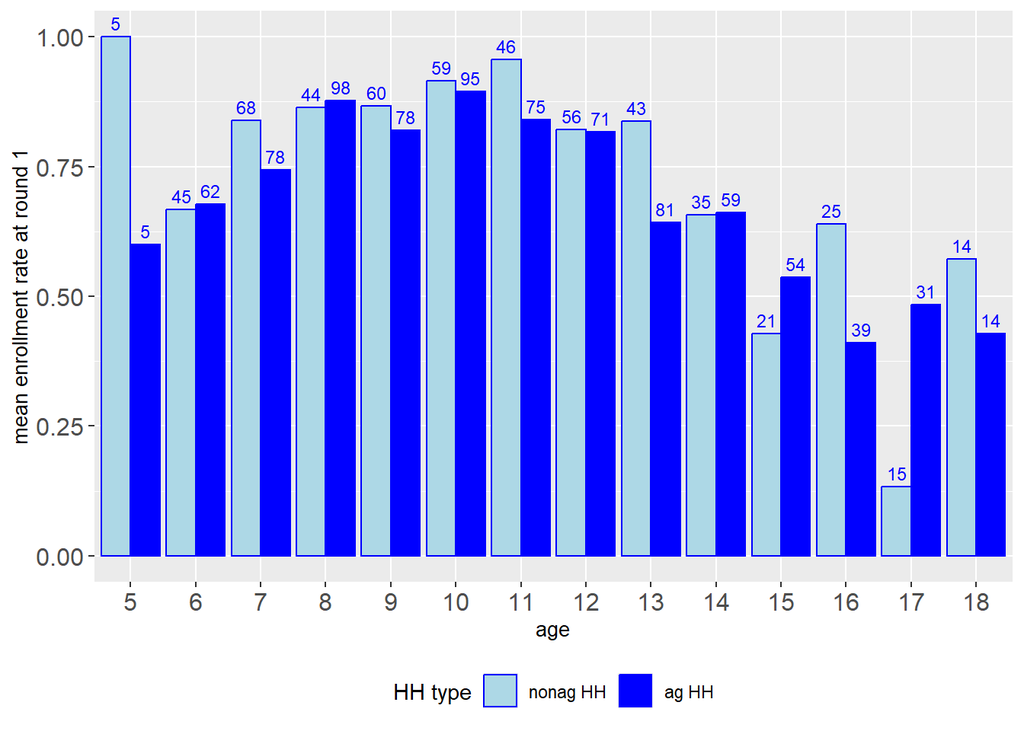

```r
library(ggplot2)
g2 <- ggplot(data = adyr,
    aes(x = year_, y = MeanAgeAtG1,
      group = agHH0, fill = agHH0, colour = agHH0, label = N)) +
  geom_col(position = "dodge") +
  scale_fill_manual(values = c("lightblue", "blue")) +
  scale_colour_manual(values = c("blue", "blue")) +
  scale_x_continuous(breaks = 1987:2000, expand=c(.04, .04)) +
  ThisThemeEnd+
  geom_text(vjust = -0.5, size = 3, position = position_dodge(width = 0.9),
    show.legend = F)+
  xlab("year of starting primary school") +
  ylab("mean age") +
  labs(color  = "HH type", fill = "HH type", label = "cell size") +
  guides(
    colour = guide_legend(title = "HH type", nrow = 1),
    label = guide_legend(title = "cell size", nrow = 1),
    fill = guide_legend(title = "HH type", nrow = 1)
    )
pdf(
  "../save/AgeAtClass1Enrollment.pdf"
  , width = 2*12/2.54, height = 2*6/2.54)
print(g2)
whatever <- dev.off()
```

- Enrollment rates are lower for agricultural than non-agricultural households at the baseline.
- Differences between agricltural and non-agricultural households in cross sectional (=between age) enrollment rate decline are not monotone. I.e., it is not that the agricultural households show faster decline between ages.

Age at class 1 enrollment. Values above each bar are total number of observations.

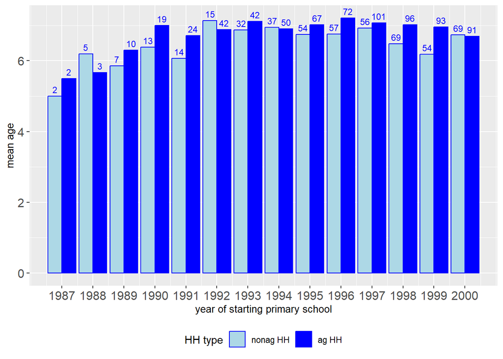

- Mean age of first enrollment is generally older than 6 for both household groups.
- Mean age of first enrollment is older among the agricultural households.

# Memo on FD and DID

FD and raw DID are numerically identical in a two-period panel. In a longer panel, they differ. FD automatically controls for individual FEs while DID needs explicit inclusion of individual dummy variables. Unfortunately, adding FEs explicitly at the individual level by using dummy variables, with the order of hundreds to thousands, is practically infeasible to implement in estimation. So most econometric programs use either FD or FE implementation. FE implementation subtracts individual means of each variables and thus requires degree of freedom correction (reduction by a single period, or subtracting the total number of cross sectional units $J$, so $JT-K-J=J(T-1)-K$). In a longer panel, it has been discussed that the choice of FD or FE depends on error persistence: If errors are close to a unit root process, FD is more efficient. If errors are closer to a white noise process, FE is more efficient (Wooldridge 2010).

Wooldridge, Jeffrey M. 2010. *Econometric Analysis of Cross Section and Panel Data*. MIT Press. http://www.sciencedirect.com/science/article/pii/S0165176509001487.

[output not shown]